# **DATA CLEANING AND PREPARATION**

```python
import numpy as np
import pandas as pd
```

```python
df_econ = pd.read_csv("/content/drive/MyDrive/FINAL-PROJECT-ML/economy.csv")
df_econ.head()
```

|  | date | airline | ch_code | num_code | dep_time | from | time_taken | stop | arr_time | to | price |
| --- | --- | --- | --- | --- | --- | --- | --- | --- | --- | --- | --- |
| 0 | 11-02-2022 | SpiceJet | SG | 8709 | 18:55 | Delhi | 02h 10m | non-stop | 21:05 | Mumbai | 5,953 |
| 1 | 11-02-2022 | SpiceJet | SG | 8157 | 06:20 | Delhi | 02h 20m | non-stop | 08:40 | Mumbai | 5,953 |
| 2 | 11-02-2022 | AirAsia | I5 | 764 | 04:25 | Delhi | 02h 10m | non-stop | 06:35 | Mumbai | 5,956 |
| 3 | 11-02-2022 | Vistara | UK | 995 | 10:20 | Delhi | 02h 15m | non-stop | 12:35 | Mumbai | 5,955 |
| 4 | 11-02-2022 | Vistara | UK | 963 | 08:50 | Delhi | 02h 20m | non-stop | 11:10 | Mumbai | 5,955 |

```python
df_buss = pd.read_csv("/content/drive/MyDrive/FINAL-PROJECT-ML/business.csv")
df_buss.head()
```

|  | date | airline | ch_code | num_code | dep_time | from | time_taken | stop | arr_time | to | price |
| --- | --- | --- | --- | --- | --- | --- | --- | --- | --- | --- | --- |
| 0 | 11-02-2022 | Air India | AI | 868 | 18:00 | Delhi | 02h 00m | non-stop | 20:00 | Mumbai | 25,612 |
| 1 | 11-02-2022 | Air India | AI | 624 | 19:00 | Delhi | 02h 15m | non-stop | 21:15 | Mumbai | 25,612 |
| 2 | 11-02-2022 | Air India | AI | 531 | 20:00 | Delhi | 24h 45m | 1-stop\n\t\t\t\t\t\t\t\t\t\t\t\t\n\t\t\t\t\t\t... | 20:45 | Mumbai | 42,220 |
| 3 | 11-02-2022 | Air India | AI | 839 | 21:25 | Delhi | 26h 30m | 1-stop\n\t\t\t\t\t\t\t\t\t\t\t\t\n\t\t\t\t\t\t... | 23:55 | Mumbai | 44,450 |
| 4 | 11-02-2022 | Air India | AI | 544 | 17:15 | Delhi | 06h 40m | 1-stop\n\t\t\t\t\t\t\t\t\t\t\t\t\n\t\t\t\t\t\t... | 23:55 | Mumbai | 46,690 |

```python
print("Shape of Economy Dataframe:", df_econ.shape)
print("Shape of Business Dataframe:", df_buss.shape)
```

```
Shape of Economy Dataframe: (206774, 11)
Shape of Business Dataframe: (93487, 11)
```

## **From the above we can observe that the `stop` column contains some unwanted tags inside them, so we're cleaning them to maintain consistency.**

```python
df_buss["stop"].value_counts()
```

```
stop
1-stop\n\t\t\t\t\t\t\t\t\t\t\t\t\n\t\t\t\t\t\t\t\t\t\t\t\t                   81489
non-stop                                                                      8102
2+-stop                                                                       1083
1-stop\n\t\t\t\t\t\t\t\t\t\t\t\tVia IDR\n\t\t\t\t\t\t\t\t\t\t\t\t              810
1-stop\n\t\t\t\t\t\t\t\t\t\t\t\tVia IXU\n\t\t\t\t\t\t\t\t\t\t\t\t              776
1-stop\n\t\t\t\t\t\t\t\t\t\t\t\tVia PAT\n\t\t\t\t\t\t\t\t\t\t\t\t              257
1-stop\n\t\t\t\t\t\t\t\t\t\t\t\tVia Patna\n\t\t\t\t\t\t\t\t\t\t\t\t            242
1-stop\n\t\t\t\t\t\t\t\t\t\t\t\tVia BBI\n\t\t\t\t\t\t\t\t\t\t\t\t              152
1-stop\n\t\t\t\t\t\t\t\t\t\t\t\tVia STV\n\t\t\t\t\t\t\t\t\t\t\t\t               93
1-stop\n\t\t\t\t\t\t\t\t\t\t\t\tVia IXE\n\t\t\t\t\t\t\t\t\t\t\t\t               86
1-stop\n\t\t\t\t\t\t\t\t\t\t\t\tVia Bhubaneswar\n\t\t\t\t\t\t\t\t\t\t\t\t       75
1-stop\n\t\t\t\t\t\t\t\t\t\t\t\tVia Hyderabad\n\t\t\t\t\t\t\t\t\t\t\t\t         71
1-stop\n\t\t\t\t\t\t\t\t\t\t\t\tVia Delhi\n\t\t\t\t\t\t\t\t\t\t\t\t             59
1-stop\n\t\t\t\t\t\t\t\t\t\t\t\tVia Raipur\n\t\t\t\t\t\t\t\t\t\t\t\t            43
1-stop\n\t\t\t\t\t\t\t\t\t\t\t\tVia Chennai\n\t\t\t\t\t\t\t\t\t\t\t\t           42
1-stop\n\t\t\t\t\t\t\t\t\t\t\t\tVia Guwahati\n\t\t\t\t\t\t\t\t\t\t\t\t          29
1-stop\n\t\t\t\t\t\t\t\t\t\t\t\tVia VTZ\n\t\t\t\t\t\t\t\t\t\t\t\t               17
1-stop\n\t\t\t\t\t\t\t\t\t\t\t\tVia NDC\n\t\t\t\t\t\t\t\t\t\t\t\t               14
1-stop\n\t\t\t\t\t\t\t\t\t\t\t\tVia Kolkata\n\t\t\t\t\t\t\t\t\t\t\t\t           14
1-stop\n\t\t\t\t\t\t\t\t\t\t\t\tVia RPR\n\t\t\t\t\t\t\t\t\t\t\t\t               13
1-stop\n\t\t\t\t\t\t\t\t\t\t\t\tVia Lucknow\n\t\t\t\t\t\t\t\t\t\t\t\t           10
1-stop\n\t\t\t\t\t\t\t\t\t\t\t\tVia GAU\n\t\t\t\t\t\t\t\t\t\t\t\t                3
1-stop\n\t\t\t\t\t\t\t\t\t\t\t\tVia GAY\n\t\t\t\t\t\t\t\t\t\t\t\t                3
1-stop\n\t\t\t\t\t\t\t\t\t\t\t\tVia Surat\n\t\t\t\t\t\t\t\t\t\t\t\t              3
1-stop\n\t\t\t\t\t\t\t\t\t\t\t\tVia HYD\n\t\t\t\t\t\t\t\t\t\t\t\t                1
Name: count, dtype: int64
```

```python
import re
df_buss["stop"] = df_buss["stop"].apply(lambda x: re.findall(r'(.+stop)', x)[0])
df_buss.head()
```

|  | date | airline | ch_code | num_code | dep_time | from | time_taken | stop | arr_time | to | price |
| --- | --- | --- | --- | --- | --- | --- | --- | --- | --- | --- | --- |
| 0 | 11-02-2022 | Air India | AI | 868 | 18:00 | Delhi | 02h 00m | non-stop | 20:00 | Mumbai | 25,612 |
| 1 | 11-02-2022 | Air India | AI | 624 | 19:00 | Delhi | 02h 15m | non-stop | 21:15 | Mumbai | 25,612 |
| 2 | 11-02-2022 | Air India | AI | 531 | 20:00 | Delhi | 24h 45m | 1-stop | 20:45 | Mumbai | 42,220 |
| 3 | 11-02-2022 | Air India | AI | 839 | 21:25 | Delhi | 26h 30m | 1-stop | 23:55 | Mumbai | 44,450 |
| 4 | 11-02-2022 | Air India | AI | 544 | 17:15 | Delhi | 06h 40m | 1-stop | 23:55 | Mumbai | 46,690 |

```python
df_econ["stop"].value_counts()
```

```
stop
1-stop\n\t\t\t\t\t\t\t\t\t\t\t\t\n\t\t\t\t\t\t\t\t\t\t\t\t                      162114
non-stop                                                                         27942
2+-stop                                                                          12205
1-stop\n\t\t\t\t\t\t\t\t\t\t\t\tVia IXU\n\t\t\t\t\t\t\t\t\t\t\t\t                 1063
1-stop\n\t\t\t\t\t\t\t\t\t\t\t\tVia IDR\n\t\t\t\t\t\t\t\t\t\t\t\t                  588
1-stop\n\t\t\t\t\t\t\t\t\t\t\t\tVia Patna\n\t\t\t\t\t\t\t\t\t\t\t\t                432
1-stop\n\t\t\t\t\t\t\t\t\t\t\t\tVia Indore\n\t\t\t\t\t\t\t\t\t\t\t\t               381
1-stop\n\t\t\t\t\t\t\t\t\t\t\t\tVia MYQ\n\t\t\t\t\t\t\t\t\t\t\t\t                  321
1-stop\n\t\t\t\t\t\t\t\t\t\t\t\tVia KLH\n\t\t\t\t\t\t\t\t\t\t\t\t                  284
1-stop\n\t\t\t\t\t\t\t\t\t\t\t\tVia Bhubaneswar\n\t\t\t\t\t\t\t\t\t\t\t\t          226
1-stop\n\t\t\t\t\t\t\t\t\t\t\t\tVia JGB\n\t\t\t\t\t\t\t\t\t\t\t\t                  193
1-stop\n\t\t\t\t\t\t\t\t\t\t\t\tVia JRG\n\t\t\t\t\t\t\t\t\t\t\t\t                  175
1-stop\n\t\t\t\t\t\t\t\t\t\t\t\tVia Ranchi\n\t\t\t\t\t\t\t\t\t\t\t\t               114
1-stop\n\t\t\t\t\t\t\t\t\t\t\t\tVia PAT\n\t\t\t\t\t\t\t\t\t\t\t\t                   97
1-stop\n\t\t\t\t\t\t\t\t\t\t\t\tVia Delhi\n\t\t\t\t\t\t\t\t\t\t\t\t                 94
1-stop\n\t\t\t\t\t\t\t\t\t\t\t\tVia STV\n\t\t\t\t\t\t\t\t\t\t\t\t                   76
1-stop\n\t\t\t\t\t\t\t\t\t\t\t\tVia Hyderabad\n\t\t\t\t\t\t\t\t\t\t\t\t             72
1-stop\n\t\t\t\t\t\t\t\t\t\t\t\tVia Raipur\n\t\t\t\t\t\t\t\t\t\t\t\t                59
1-stop\n\t\t\t\t\t\t\t\t\t\t\t\tVia Mysore\n\t\t\t\t\t\t\t\t\t\t\t\t                45
1-stop\n\t\t\t\t\t\t\t\t\t\t\t\tVia Mangalore\n\t\t\t\t\t\t\t\t\t\t\t\t             39
1-stop\n\t\t\t\t\t\t\t\t\t\t\t\tVia Chennai\n\t\t\t\t\t\t\t\t\t\t\t\t               35
1-stop\n\t\t\t\t\t\t\t\t\t\t\t\tVia IXE\n\t\t\t\t\t\t\t\t\t\t\t\t                   34
1-stop\n\t\t\t\t\t\t\t\t\t\t\t\tVia Mumbai\n\t\t\t\t\t\t\t\t\t\t\t\t                31
1-stop\n\t\t\t\t\t\t\t\t\t\t\t\tVia Guwahati\n\t\t\t\t\t\t\t\t\t\t\t\t              26
1-stop\n\t\t\t\t\t\t\t\t\t\t\t\tVia Nagpur\n\t\t\t\t\t\t\t\t\t\t\t\t                25
1-stop\n\t\t\t\t\t\t\t\t\t\t\t\tVia GOP\n\t\t\t\t\t\t\t\t\t\t\t\t                   16
1-stop\n\t\t\t\t\t\t\t\t\t\t\t\tVia Kolkata\n\t\t\t\t\t\t\t\t\t\t\t\t               14
1-stop\n\t\t\t\t\t\t\t\t\t\t\t\tVia Surat\n\t\t\t\t\t\t\t\t\t\t\t\t                 11
1-stop\n\t\t\t\t\t\t\t\t\t\t\t\tVia VTZ\n\t\t\t\t\t\t\t\t\t\t\t\t                   10
1-stop\n\t\t\t\t\t\t\t\t\t\t\t\tVia RPR\n\t\t\t\t\t\t\t\t\t\t\t\t                    9
1-stop\n\t\t\t\t\t\t\t\t\t\t\t\tVia NAG\n\t\t\t\t\t\t\t\t\t\t\t\t                    9
1-stop\n\t\t\t\t\t\t\t\t\t\t\t\tVia NDC\n\t\t\t\t\t\t\t\t\t\t\t\t                    8
1-stop\n\t\t\t\t\t\t\t\t\t\t\t\tVia Vishakhapatnam\n\t\t\t\t\t\t\t\t\t\t\t\t         8
1-stop\n\t\t\t\t\t\t\t\t\t\t\t\tVia BBI\n\t\t\t\t\t\t\t\t\t\t\t\t                    6
1-stop\n\t\t\t\t\t\t\t\t\t\t\t\tVia Kolhapur\n\t\t\t\t\t\t\t\t\t\t\t\t               5
1-stop\n\t\t\t\t\t\t\t\t\t\t\t\tVia IXR\n\t\t\t\t\t\t\t\t\t\t\t\t                    4
1-stop\n\t\t\t\t\t\t\t\t\t\t\t\tVia Lucknow\n\t\t\t\t\t\t\t\t\t\t\t\t                3
Name: count, dtype: int64
```

```python
df_econ["stop"] = df_econ["stop"].apply(lambda x: re.findall(r'(.+stop)', x)[0])
df_econ.head()
```

|  | date | airline | ch_code | num_code | dep_time | from | time_taken | stop | arr_time | to | price |
| --- | --- | --- | --- | --- | --- | --- | --- | --- | --- | --- | --- |
| 0 | 11-02-2022 | SpiceJet | SG | 8709 | 18:55 | Delhi | 02h 10m | non-stop | 21:05 | Mumbai | 5,953 |
| 1 | 11-02-2022 | SpiceJet | SG | 8157 | 06:20 | Delhi | 02h 20m | non-stop | 08:40 | Mumbai | 5,953 |
| 2 | 11-02-2022 | AirAsia | I5 | 764 | 04:25 | Delhi | 02h 10m | non-stop | 06:35 | Mumbai | 5,956 |
| 3 | 11-02-2022 | Vistara | UK | 995 | 10:20 | Delhi | 02h 15m | non-stop | 12:35 | Mumbai | 5,955 |
| 4 | 11-02-2022 | Vistara | UK | 963 | 08:50 | Delhi | 02h 20m | non-stop | 11:10 | Mumbai | 5,955 |

```python
df_buss["stop"].value_counts()
```

```
stop
1-stop      84302
non-stop     8102
2+-stop      1083
Name: count, dtype: int64
```

```python
df_econ["stop"].value_counts()
```

```
stop
1-stop      166627
non-stop     27942
2+-stop      12205
Name: count, dtype: int64
```

### **converting them to simpler categorical values to ease our understanding.**

```python
def stop_change(x):
    if x == "non-stop":
        return "zero"
    elif x == "1-stop":
        return "one"
    else:
        return "multiple"
```

```python
df_buss.head()
```

|  | date | airline | ch_code | num_code | dep_time | from | time_taken | stop | arr_time | to | price |
| --- | --- | --- | --- | --- | --- | --- | --- | --- | --- | --- | --- |
| 0 | 11-02-2022 | Air India | AI | 868 | 18:00 | Delhi | 02h 00m | non-stop | 20:00 | Mumbai | 25,612 |
| 1 | 11-02-2022 | Air India | AI | 624 | 19:00 | Delhi | 02h 15m | non-stop | 21:15 | Mumbai | 25,612 |
| 2 | 11-02-2022 | Air India | AI | 531 | 20:00 | Delhi | 24h 45m | 1-stop | 20:45 | Mumbai | 42,220 |
| 3 | 11-02-2022 | Air India | AI | 839 | 21:25 | Delhi | 26h 30m | 1-stop | 23:55 | Mumbai | 44,450 |
| 4 | 11-02-2022 | Air India | AI | 544 | 17:15 | Delhi | 06h 40m | 1-stop | 23:55 | Mumbai | 46,690 |

```python
df_buss["stops"] = df_buss["stop"].apply(lambda x: stop_change(x))
df_buss = df_buss.drop(columns=["stop"])
df_buss["stops"].value_counts()
```

```
stops
one         84302
zero         8102
multiple     1083
Name: count, dtype: int64
```

```python
df_econ["stops"] = df_econ["stop"].apply(lambda x: stop_change(x))
df_econ = df_econ.drop(["stop"],axis=1)
df_econ["stops"].value_counts()
```

```
stops
one         166627
zero         27942
multiple     12205
Name: count, dtype: int64
```

## **Checking for null values.**

```python
df_econ.info()
```

```
<class 'pandas.core.frame.DataFrame'>
RangeIndex: 206774 entries, 0 to 206773
Data columns (total 11 columns):
 #   Column      Non-Null Count   Dtype
---  ------      --------------   -----
 0   date        206774 non-null  object
 1   airline     206774 non-null  object
 2   ch_code     206774 non-null  object
 3   num_code    206774 non-null  int64
 4   dep_time    206774 non-null  object
 5   from        206774 non-null  object
 6   time_taken  206774 non-null  object
 7   arr_time    206774 non-null  object
 8   to          206774 non-null  object
 9   price       206774 non-null  object
 10  stops       206774 non-null  object
dtypes: int64(1), object(10)
memory usage: 17.4+ MB
```

```python
df_econ.isna().sum()
```

```
date          0
airline       0
ch_code       0
num_code      0
dep_time      0
from          0
time_taken    0
arr_time      0
to            0
price         0
stops         0
dtype: int64
```

```python
df_buss.info()
```

```
<class 'pandas.core.frame.DataFrame'>
RangeIndex: 93487 entries, 0 to 93486
Data columns (total 11 columns):
 #   Column      Non-Null Count  Dtype
---  ------      --------------  -----
 0   date        93487 non-null  object
 1   airline     93487 non-null  object
 2   ch_code     93487 non-null  object
 3   num_code    93487 non-null  int64
 4   dep_time    93487 non-null  object
 5   from        93487 non-null  object
 6   time_taken  93487 non-null  object
 7   arr_time    93487 non-null  object
 8   to          93487 non-null  object
 9   price       93487 non-null  object
 10  stops       93487 non-null  object
dtypes: int64(1), object(10)
memory usage: 7.8+ MB
```

```python
df_buss.isna().sum()
```

```
date          0
airline       0
ch_code       0
num_code      0
dep_time      0
from          0
time_taken    0
arr_time      0
to            0
price         0
stops         0
dtype: int64
```

## **From the above we can observe that our datasets doesn't contain any null values. We can observe that many of the columns are of the wrong data types, so we need to convert them to the right data types too.**

```python
df_buss.head()
```

|  | date | airline | ch_code | num_code | dep_time | from | time_taken | arr_time | to | price | stops |
| --- | --- | --- | --- | --- | --- | --- | --- | --- | --- | --- | --- |
| 0 | 11-02-2022 | Air India | AI | 868 | 18:00 | Delhi | 02h 00m | 20:00 | Mumbai | 25,612 | zero |
| 1 | 11-02-2022 | Air India | AI | 624 | 19:00 | Delhi | 02h 15m | 21:15 | Mumbai | 25,612 | zero |
| 2 | 11-02-2022 | Air India | AI | 531 | 20:00 | Delhi | 24h 45m | 20:45 | Mumbai | 42,220 | one |
| 3 | 11-02-2022 | Air India | AI | 839 | 21:25 | Delhi | 26h 30m | 23:55 | Mumbai | 44,450 | one |
| 4 | 11-02-2022 | Air India | AI | 544 | 17:15 | Delhi | 06h 40m | 23:55 | Mumbai | 46,690 | one |

```python
df_buss["airline"].value_counts(),df_buss["airline"].unique()
```

```
(airline
 Vistara      60589
 Air India    32898
 Name: count, dtype: int64,
 array(['Air India', 'Vistara'], dtype=object))
```

```python
df_econ["airline"].value_counts(),df_econ["airline"].unique()
```

```
(airline
 Vistara      67270
 Air India    47996
 Indigo       43120
 GO FIRST     23177
 AirAsia      16098
 SpiceJet      9011
 StarAir         61
 Trujet          41
 Name: count, dtype: int64,
 array(['SpiceJet', 'AirAsia', 'Vistara', 'GO FIRST', 'Indigo',
        'Air India', 'Trujet', 'StarAir'], dtype=object))
```

## **From the above we can observe that only two airlines are providing the business class flights, these flights are from `Air India` and `Vistara`. Whereas we have around 8 airlines including Air India and Vistara providing the Economy class experience.**

## **combining the `ch_code` and `num_code` for a better representation of the flights identity.**

```python
df_buss["ch_code"].value_counts()
```

```
ch_code
UK    60589
AI    32898
Name: count, dtype: int64
```

```python
df_buss["num_code"].value_counts()
```

```
num_code
808    1644
706    1429
774    1348
772    1334
720    1230
       ...
551       3
891       2
487       2
583       2
437       1
Name: count, Length: 264, dtype: int64
```

```python
df_econ["ch_code"].value_counts()
```

```
ch_code
UK    67270
AI    47996
6E    43120
G8    23177
I5    16098
SG     9011
S5       61
2T       41
Name: count, dtype: int64
```

```python
df_econ["num_code"].value_counts()
```

```
num_code
706     1806
808     1669
822     1529
772     1526
774     1460
        ...
9923       1
6474       1
405        1
2914       1
2939       1
Name: count, Length: 1254, dtype: int64
```

```python
df_buss["flight"] = [i+"-"+str(j) for i,j in zip(df_buss["ch_code"],df_buss["num_code"])]
df_buss.head()
```

|  | date | airline | ch_code | num_code | dep_time | from | time_taken | arr_time | to | price | stops | flight |
| --- | --- | --- | --- | --- | --- | --- | --- | --- | --- | --- | --- | --- |
| 0 | 11-02-2022 | Air India | AI | 868 | 18:00 | Delhi | 02h 00m | 20:00 | Mumbai | 25,612 | zero | AI-868 |
| 1 | 11-02-2022 | Air India | AI | 624 | 19:00 | Delhi | 02h 15m | 21:15 | Mumbai | 25,612 | zero | AI-624 |
| 2 | 11-02-2022 | Air India | AI | 531 | 20:00 | Delhi | 24h 45m | 20:45 | Mumbai | 42,220 | one | AI-531 |
| 3 | 11-02-2022 | Air India | AI | 839 | 21:25 | Delhi | 26h 30m | 23:55 | Mumbai | 44,450 | one | AI-839 |
| 4 | 11-02-2022 | Air India | AI | 544 | 17:15 | Delhi | 06h 40m | 23:55 | Mumbai | 46,690 | one | AI-544 |

```python
df_buss = df_buss.drop(["ch_code","num_code"],axis=1)
df_buss.head()
```

|  | date | airline | dep_time | from | time_taken | arr_time | to | price | stops | flight |
| --- | --- | --- | --- | --- | --- | --- | --- | --- | --- | --- |
| 0 | 11-02-2022 | Air India | 18:00 | Delhi | 02h 00m | 20:00 | Mumbai | 25,612 | zero | AI-868 |
| 1 | 11-02-2022 | Air India | 19:00 | Delhi | 02h 15m | 21:15 | Mumbai | 25,612 | zero | AI-624 |
| 2 | 11-02-2022 | Air India | 20:00 | Delhi | 24h 45m | 20:45 | Mumbai | 42,220 | one | AI-531 |
| 3 | 11-02-2022 | Air India | 21:25 | Delhi | 26h 30m | 23:55 | Mumbai | 44,450 | one | AI-839 |
| 4 | 11-02-2022 | Air India | 17:15 | Delhi | 06h 40m | 23:55 | Mumbai | 46,690 | one | AI-544 |

```python
df_econ["flight"] = [i+"-"+str(j) for i,j in zip(df_econ["ch_code"],df_econ["num_code"])]
df_econ = df_econ.drop(["ch_code","num_code"],axis=1)
df_econ.head()
```

|  | date | airline | dep_time | from | time_taken | arr_time | to | price | stops | flight |
| --- | --- | --- | --- | --- | --- | --- | --- | --- | --- | --- |
| 0 | 11-02-2022 | SpiceJet | 18:55 | Delhi | 02h 10m | 21:05 | Mumbai | 5,953 | zero | SG-8709 |
| 1 | 11-02-2022 | SpiceJet | 06:20 | Delhi | 02h 20m | 08:40 | Mumbai | 5,953 | zero | SG-8157 |
| 2 | 11-02-2022 | AirAsia | 04:25 | Delhi | 02h 10m | 06:35 | Mumbai | 5,956 | zero | I5-764 |
| 3 | 11-02-2022 | Vistara | 10:20 | Delhi | 02h 15m | 12:35 | Mumbai | 5,955 | zero | UK-995 |
| 4 | 11-02-2022 | Vistara | 08:50 | Delhi | 02h 20m | 11:10 | Mumbai | 5,955 | zero | UK-963 |

```python
df_buss["from"].value_counts(),df_buss["from"].unique()
```

```
(from
 Mumbai       19858
 Delhi        18316
 Bangalore    16441
 Kolkata      13473
 Hyderabad    12870
 Chennai      12529
 Name: count, dtype: int64,
 array(['Delhi', 'Mumbai', 'Bangalore', 'Kolkata', 'Hyderabad', 'Chennai'],
       dtype=object))
```

```python
df_econ["from"].value_counts(),df_econ["from"].unique()
```

```
(from
 Delhi        43029
 Mumbai       41045
 Bangalore    35665
 Kolkata      32874
 Hyderabad    27990
 Chennai      26171
 Name: count, dtype: int64,
 array(['Delhi', 'Mumbai', 'Bangalore', 'Kolkata', 'Hyderabad', 'Chennai'],
       dtype=object))
```

## **From the above we can see that the flights travel bewteen the famous 6 cities of India. They are namely 'Delhi', 'Mumbai', 'Bangalore', 'Kolkata', 'Hyderabad' and 'Chennai'.**

```python
df_econ["price"].value_counts().head()
```

```
price
2,339    1442
5,949    1196
5,955    1138
6,489    1082
6,067    1063
Name: count, dtype: int64
```

```python
df_buss["price"].value_counts().head()
```

```
price
54,608    1445
54,684    1390
60,978    1383
60,508    1230
49,725    1205
Name: count, dtype: int64
```

## **Cleaning the `price` column and assigning the right data type.**

```python
df_econ['price'] = df_econ['price'].str.replace(',', '').astype(float)
df_buss['price'] = df_buss['price'].str.replace(',', '').astype(float)
df_econ["price"].head(),df_buss["price"].head()
```

```
(0    5953.0
 1    5953.0
 2    5956.0
 3    5955.0
 4    5955.0
 Name: price, dtype: float64,
 0    25612.0
 1    25612.0
 2    42220.0
 3    44450.0
 4    46690.0
 Name: price, dtype: float64)
```

## **Converting the `date` from "object" to "datetime" data type.**

```python
df_buss["date"].head(),df_econ["date"].head()
```

```
(0    11-02-2022
 1    11-02-2022
 2    11-02-2022
 3    11-02-2022
 4    11-02-2022
 Name: date, dtype: object,
 0    11-02-2022
 1    11-02-2022
 2    11-02-2022
 3    11-02-2022
 4    11-02-2022
 Name: date, dtype: object)
```

```python
pd.to_datetime(df_buss["date"], format='%d-%m-%Y').head()
```

```
0   2022-02-11
1   2022-02-11
2   2022-02-11
3   2022-02-11
4   2022-02-11
Name: date, dtype: datetime64[ns]
```

```python
df_buss["date"] = pd.to_datetime(df_buss["date"], format='%d-%m-%Y')
df_econ["date"] = pd.to_datetime(df_econ["date"], format='%d-%m-%Y')
df_buss["date"].head(),df_econ["date"].head()
```

```
(0   2022-02-11
 1   2022-02-11
 2   2022-02-11
 3   2022-02-11
 4   2022-02-11
 Name: date, dtype: datetime64[ns],
 0   2022-02-11
 1   2022-02-11
 2   2022-02-11
 3   2022-02-11
 4   2022-02-11
 Name: date, dtype: datetime64[ns])
```

```python
df_buss["dep_time"].head()
```

```
0    18:00
1    19:00
2    20:00
3    21:25
4    17:15
Name: dep_time, dtype: object
```

```python
pd.to_datetime(df_buss['dep_time'], format='%H:%M')
```

```
0       1900-01-01 18:00:00
1       1900-01-01 19:00:00
2       1900-01-01 20:00:00
3       1900-01-01 21:25:00
4       1900-01-01 17:15:00
                ...
93482   1900-01-01 09:45:00
93483   1900-01-01 12:30:00
93484   1900-01-01 07:05:00
93485   1900-01-01 07:00:00
93486   1900-01-01 09:45:00
Name: dep_time, Length: 93487, dtype: datetime64[ns]
```

```python
pd.to_datetime(df_buss['dep_time'], format='%H:%M').dt.time
```

```
0        18:00:00
1        19:00:00
2        20:00:00
3        21:25:00
4        17:15:00
           ...
93482    09:45:00
93483    12:30:00
93484    07:05:00
93485    07:00:00
93486    09:45:00
Name: dep_time, Length: 93487, dtype: object
```

```python
df_econ["dep_time"] = pd.to_datetime(df_econ['dep_time'], format='%H:%M').dt.time
df_econ["arr_time"] = pd.to_datetime(df_econ['arr_time'], format='%H:%M').dt.time
df_buss["dep_time"] = pd.to_datetime(df_buss['dep_time'], format='%H:%M').dt.time
df_buss["arr_time"] = pd.to_datetime(df_buss['arr_time'], format='%H:%M').dt.time
df_econ["dep_time"].head(),df_buss["dep_time"].head()
```

```
(0    18:55:00
 1    06:20:00
 2    04:25:00
 3    10:20:00
 4    08:50:00
 Name: dep_time, dtype: object,
 0    18:00:00
 1    19:00:00
 2    20:00:00
 3    21:25:00
 4    17:15:00
 Name: dep_time, dtype: object)
```

```python
df_buss.head()
```

|  | date | airline | dep_time | from | time_taken | arr_time | to | price | stops | flight |
| --- | --- | --- | --- | --- | --- | --- | --- | --- | --- | --- |
| 0 | 2022-02-11 | Air India | 18:00:00 | Delhi | 02h 00m | 20:00:00 | Mumbai | 25612.0 | zero | AI-868 |
| 1 | 2022-02-11 | Air India | 19:00:00 | Delhi | 02h 15m | 21:15:00 | Mumbai | 25612.0 | zero | AI-624 |
| 2 | 2022-02-11 | Air India | 20:00:00 | Delhi | 24h 45m | 20:45:00 | Mumbai | 42220.0 | one | AI-531 |
| 3 | 2022-02-11 | Air India | 21:25:00 | Delhi | 26h 30m | 23:55:00 | Mumbai | 44450.0 | one | AI-839 |
| 4 | 2022-02-11 | Air India | 17:15:00 | Delhi | 06h 40m | 23:55:00 | Mumbai | 46690.0 | one | AI-544 |

## **Generating a new column `duration` representing the duration of the flight journey. Made using the previous `time taken` column.**

```python
df_buss['time_taken'] = df_buss['time_taken'].apply(lambda x: pd.to_timedelta(x.replace('h', ' hours ').replace('m', ' minutes')))
df_buss['time_taken'].head()
```

```
0   0 days 02:00:00
1   0 days 02:15:00
2   1 days 00:45:00
3   1 days 02:30:00
4   0 days 06:40:00
Name: time_taken, dtype: timedelta64[ns]
```

```python
df_buss['duration'] = np.round(df_buss['time_taken'].dt.total_seconds() / 3600,2)
df_buss.head()
```

|  | date | airline | dep_time | from | time_taken | arr_time | to | price | stops | flight | duration |
| --- | --- | --- | --- | --- | --- | --- | --- | --- | --- | --- | --- |
| 0 | 2022-02-11 | Air India | 18:00:00 | Delhi | 0 days 02:00:00 | 20:00:00 | Mumbai | 25612.0 | zero | AI-868 | 2.00 |
| 1 | 2022-02-11 | Air India | 19:00:00 | Delhi | 0 days 02:15:00 | 21:15:00 | Mumbai | 25612.0 | zero | AI-624 | 2.25 |
| 2 | 2022-02-11 | Air India | 20:00:00 | Delhi | 1 days 00:45:00 | 20:45:00 | Mumbai | 42220.0 | one | AI-531 | 24.75 |
| 3 | 2022-02-11 | Air India | 21:25:00 | Delhi | 1 days 02:30:00 | 23:55:00 | Mumbai | 44450.0 | one | AI-839 | 26.50 |
| 4 | 2022-02-11 | Air India | 17:15:00 | Delhi | 0 days 06:40:00 | 23:55:00 | Mumbai | 46690.0 | one | AI-544 | 6.67 |

```python
df_econ["time_taken"].value_counts()
```

```
time_taken
02h 10m    3081
02h 15m    2912
02h 45m    2006
02h 05m    1969
02h 50m    1723
           ...
47h 45m       1
38h 30m       1
42h 00m       1
1.01h m       1
41h 30m       1
Name: count, Length: 483, dtype: int64
```

```python
df_econ[df_econ["time_taken"].apply(lambda x: True if "h m" in x else False)]
```

|  | date | airline | dep_time | from | time_taken | arr_time | to | price | stops | flight |
| --- | --- | --- | --- | --- | --- | --- | --- | --- | --- | --- |
| 96486 | 2022-02-26 | GO FIRST | 05:45:00 | Bangalore | 1.03h m | 09:10:00 | Mumbai | 5177.0 | one | G8-146 |
| 104676 | 2022-02-26 | GO FIRST | 05:45:00 | Bangalore | 1.02h m | 08:00:00 | Kolkata | 5177.0 | multiple | G8-146 |
| 111315 | 2022-02-26 | GO FIRST | 05:45:00 | Bangalore | 1.03h m | 09:30:00 | Hyderabad | 4337.0 | multiple | G8-146 |
| 154007 | 2022-02-25 | GO FIRST | 20:45:00 | Hyderabad | 1.01h m | 21:50:00 | Delhi | 6132.0 | one | G8-517 |

```python
df_econ["time_taken"] =  df_econ["time_taken"].apply(lambda x: x.split(".")[0]+"h "+x.split(".")[1].replace("h m","m") if "." in x else x)
```

```python
df_econ["time_taken"].value_counts()
```

```
time_taken
02h 10m    3081
02h 15m    2912
02h 45m    2006
02h 05m    1969
02h 50m    1723
           ...
47h 45m       1
38h 30m       1
42h 00m       1
1h 01m        1
41h 30m       1
Name: count, Length: 483, dtype: int64
```

```python
df_econ['time_taken'] = df_econ['time_taken'].apply(lambda x: pd.to_timedelta(x.replace('h', ' hours ').replace('m', ' minutes')))
```

```python
df_econ['duration'] = np.round(df_econ['time_taken'].dt.total_seconds() / 3600,2)
df_econ.head()
```

|  | date | airline | dep_time | from | time_taken | arr_time | to | price | stops | flight | duration |
| --- | --- | --- | --- | --- | --- | --- | --- | --- | --- | --- | --- |
| 0 | 2022-02-11 | SpiceJet | 18:55:00 | Delhi | 0 days 02:10:00 | 21:05:00 | Mumbai | 5953.0 | zero | SG-8709 | 2.17 |
| 1 | 2022-02-11 | SpiceJet | 06:20:00 | Delhi | 0 days 02:20:00 | 08:40:00 | Mumbai | 5953.0 | zero | SG-8157 | 2.33 |
| 2 | 2022-02-11 | AirAsia | 04:25:00 | Delhi | 0 days 02:10:00 | 06:35:00 | Mumbai | 5956.0 | zero | I5-764 | 2.17 |
| 3 | 2022-02-11 | Vistara | 10:20:00 | Delhi | 0 days 02:15:00 | 12:35:00 | Mumbai | 5955.0 | zero | UK-995 | 2.25 |
| 4 | 2022-02-11 | Vistara | 08:50:00 | Delhi | 0 days 02:20:00 | 11:10:00 | Mumbai | 5955.0 | zero | UK-963 | 2.33 |

## **Binning the `departure time` and `arrival time` for to reduce the complexity of data and make it more manageable and easier to analyze.**

```python
def time_to_period(x):
    hour = x.hour
    if 5 <= hour < 12:
        return "Morning"
    elif 12 <= hour < 17:
        return "Afternoon"
    elif 17 <= hour < 21:
        return "Evening"
    else:
        return "Night"
```

```python
df_econ["dep_time"].head()
```

```
0    18:55:00
1    06:20:00
2    04:25:00
3    10:20:00
4    08:50:00
Name: dep_time, dtype: object
```

```python
df_econ['dep_time'] = df_econ['dep_time'].apply(lambda x: time_to_period(x))
df_econ['dep_time'].head()
```

```
0    Evening
1    Morning
2      Night
3    Morning
4    Morning
Name: dep_time, dtype: object
```

```python
df_econ['arr_time'] = df_econ['arr_time'].apply(lambda x: time_to_period(x))
df_econ['arr_time'].head()
```

```
0        Night
1      Morning
2      Morning
3    Afternoon
4      Morning
Name: arr_time, dtype: object
```

```python
df_buss["arr_time"] = df_buss["arr_time"].apply(lambda x: time_to_period(x))
df_buss["dep_time"] = df_buss["dep_time"].apply(lambda x: time_to_period(x))
df_buss["arr_time"].head(),df_buss["dep_time"].head()
```

```
(0    Evening
 1      Night
 2    Evening
 3      Night
 4      Night
 Name: arr_time, dtype: object,
 0    Evening
 1    Evening
 2    Evening
 3      Night
 4    Evening
 Name: dep_time, dtype: object)
```

```python
df_buss.head()
```

|  | date | airline | dep_time | from | time_taken | arr_time | to | price | stops | flight | duration |
| --- | --- | --- | --- | --- | --- | --- | --- | --- | --- | --- | --- |
| 0 | 2022-02-11 | Air India | Evening | Delhi | 0 days 02:00:00 | Evening | Mumbai | 25612.0 | zero | AI-868 | 2.00 |
| 1 | 2022-02-11 | Air India | Evening | Delhi | 0 days 02:15:00 | Night | Mumbai | 25612.0 | zero | AI-624 | 2.25 |
| 2 | 2022-02-11 | Air India | Evening | Delhi | 1 days 00:45:00 | Evening | Mumbai | 42220.0 | one | AI-531 | 24.75 |
| 3 | 2022-02-11 | Air India | Night | Delhi | 1 days 02:30:00 | Night | Mumbai | 44450.0 | one | AI-839 | 26.50 |
| 4 | 2022-02-11 | Air India | Evening | Delhi | 0 days 06:40:00 | Night | Mumbai | 46690.0 | one | AI-544 | 6.67 |

## **Generating a new column `days_left` to represent the number of days left for the flight departure from today.**

```python
current_date = pd.to_datetime('2022-02-10')

# Calculate the number of days left
df_buss['days_left'] = (df_buss['date'] - current_date).dt.days
df_econ['days_left'] = (df_econ['date'] - current_date).dt.days
df_buss.head()
```

|  | date | airline | dep_time | from | time_taken | arr_time | to | price | stops | flight | duration | days_left |
| --- | --- | --- | --- | --- | --- | --- | --- | --- | --- | --- | --- | --- |
| 0 | 2022-02-11 | Air India | Evening | Delhi | 0 days 02:00:00 | Evening | Mumbai | 25612.0 | zero | AI-868 | 2.00 | 1 |
| 1 | 2022-02-11 | Air India | Evening | Delhi | 0 days 02:15:00 | Night | Mumbai | 25612.0 | zero | AI-624 | 2.25 | 1 |
| 2 | 2022-02-11 | Air India | Evening | Delhi | 1 days 00:45:00 | Evening | Mumbai | 42220.0 | one | AI-531 | 24.75 | 1 |
| 3 | 2022-02-11 | Air India | Night | Delhi | 1 days 02:30:00 | Night | Mumbai | 44450.0 | one | AI-839 | 26.50 | 1 |
| 4 | 2022-02-11 | Air India | Evening | Delhi | 0 days 06:40:00 | Night | Mumbai | 46690.0 | one | AI-544 | 6.67 | 1 |

```python
df_buss["class"] = "Business"
df_econ["class"] = "Economy"
```

```python
df_buss = df_buss[["date","airline","flight","from","dep_time","stops","to","arr_time","class","duration","days_left","price"]]
df_buss.columns = ["date","airline","flight","from","departure_time","stops","destination","arrival_time","class","duration","days_left","price"]
df_buss.head()
```

|  | date | airline | flight | from | departure_time | stops | destination | arrival_time | class | duration | days_left | price |
| --- | --- | --- | --- | --- | --- | --- | --- | --- | --- | --- | --- | --- |
| 0 | 2022-02-11 | Air India | AI-868 | Delhi | Evening | zero | Mumbai | Evening | Business | 2.00 | 1 | 25612.0 |
| 1 | 2022-02-11 | Air India | AI-624 | Delhi | Evening | zero | Mumbai | Night | Business | 2.25 | 1 | 25612.0 |
| 2 | 2022-02-11 | Air India | AI-531 | Delhi | Evening | one | Mumbai | Evening | Business | 24.75 | 1 | 42220.0 |
| 3 | 2022-02-11 | Air India | AI-839 | Delhi | Night | one | Mumbai | Night | Business | 26.50 | 1 | 44450.0 |
| 4 | 2022-02-11 | Air India | AI-544 | Delhi | Evening | one | Mumbai | Night | Business | 6.67 | 1 | 46690.0 |

```python
df_econ = df_econ[["date","airline","flight","from","dep_time","stops","to","arr_time","class","duration","days_left","price"]]
df_econ.columns = ["date","airline","flight","from","departure_time","stops","destination","arrival_time","class","duration","days_left","price"]
df_econ.head()
```

|  | date | airline | flight | from | departure_time | stops | destination | arrival_time | class | duration | days_left | price |
| --- | --- | --- | --- | --- | --- | --- | --- | --- | --- | --- | --- | --- |
| 0 | 2022-02-11 | SpiceJet | SG-8709 | Delhi | Evening | zero | Mumbai | Night | Economy | 2.17 | 1 | 5953.0 |
| 1 | 2022-02-11 | SpiceJet | SG-8157 | Delhi | Morning | zero | Mumbai | Morning | Economy | 2.33 | 1 | 5953.0 |
| 2 | 2022-02-11 | AirAsia | I5-764 | Delhi | Night | zero | Mumbai | Morning | Economy | 2.17 | 1 | 5956.0 |
| 3 | 2022-02-11 | Vistara | UK-995 | Delhi | Morning | zero | Mumbai | Afternoon | Economy | 2.25 | 1 | 5955.0 |
| 4 | 2022-02-11 | Vistara | UK-963 | Delhi | Morning | zero | Mumbai | Morning | Economy | 2.33 | 1 | 5955.0 |

```python
df_buss.info()
```

```
<class 'pandas.core.frame.DataFrame'>
RangeIndex: 93487 entries, 0 to 93486
Data columns (total 12 columns):
 #   Column          Non-Null Count  Dtype
---  ------          --------------  -----
 0   date            93487 non-null  datetime64[ns]
 1   airline         93487 non-null  object
 2   flight          93487 non-null  object
 3   from            93487 non-null  object
 4   departure_time  93487 non-null  object
 5   stops           93487 non-null  object
 6   destination     93487 non-null  object
 7   arrival_time    93487 non-null  object
 8   class           93487 non-null  object
 9   duration        93487 non-null  float64
 10  days_left       93487 non-null  int64
 11  price           93487 non-null  float64
dtypes: datetime64[ns](1), float64(2), int64(1), object(8)
memory usage: 8.6+ MB
```

```python
df_econ.info()
```

```
<class 'pandas.core.frame.DataFrame'>
RangeIndex: 206774 entries, 0 to 206773
Data columns (total 12 columns):
 #   Column          Non-Null Count   Dtype
---  ------          --------------   -----
 0   date            206774 non-null  datetime64[ns]
 1   airline         206774 non-null  object
 2   flight          206774 non-null  object
 3   from            206774 non-null  object
 4   departure_time  206774 non-null  object
 5   stops           206774 non-null  object
 6   destination     206774 non-null  object
 7   arrival_time    206774 non-null  object
 8   class           206774 non-null  object
 9   duration        206774 non-null  float64
 10  days_left       206774 non-null  int64
 11  price           206774 non-null  float64
dtypes: datetime64[ns](1), float64(2), int64(1), object(8)
memory usage: 18.9+ MB
```

## **Combining Both the dataframes into a single dataframe**

```python
df_cleaned = pd.concat([df_buss,df_econ])
df_cleaned.head()
```

|  | date | airline | flight | from | departure_time | stops | destination | arrival_time | class | duration | days_left | price |
| --- | --- | --- | --- | --- | --- | --- | --- | --- | --- | --- | --- | --- |
| 0 | 2022-02-11 | Air India | AI-868 | Delhi | Evening | zero | Mumbai | Evening | Business | 2.00 | 1 | 25612.0 |
| 1 | 2022-02-11 | Air India | AI-624 | Delhi | Evening | zero | Mumbai | Night | Business | 2.25 | 1 | 25612.0 |
| 2 | 2022-02-11 | Air India | AI-531 | Delhi | Evening | one | Mumbai | Evening | Business | 24.75 | 1 | 42220.0 |
| 3 | 2022-02-11 | Air India | AI-839 | Delhi | Night | one | Mumbai | Night | Business | 26.50 | 1 | 44450.0 |
| 4 | 2022-02-11 | Air India | AI-544 | Delhi | Evening | one | Mumbai | Night | Business | 6.67 | 1 | 46690.0 |

```python
df_cleaned.to_csv("/content/drive/MyDrive/FINAL-PROJECT-ML/flight_data.csv",index=False)
```

# **SPRINT-2**

```python
import numpy as np
import pandas as pd
import matplotlib.pyplot as plt
import seaborn as sns

df = pd.read_csv("/content/drive/MyDrive/FINAL-PROJECT-ML/flight_data.csv")
df.head()
```

|  | date | airline | flight | from | departure_time | stops | destination | arrival_time | class | duration | days_left | price |
| --- | --- | --- | --- | --- | --- | --- | --- | --- | --- | --- | --- | --- |
| 0 | 2022-02-11 | Air India | AI-868 | Delhi | Evening | zero | Mumbai | Evening | Business | 2.00 | 1 | 25612.0 |
| 1 | 2022-02-11 | Air India | AI-624 | Delhi | Evening | zero | Mumbai | Night | Business | 2.25 | 1 | 25612.0 |
| 2 | 2022-02-11 | Air India | AI-531 | Delhi | Evening | one | Mumbai | Evening | Business | 24.75 | 1 | 42220.0 |
| 3 | 2022-02-11 | Air India | AI-839 | Delhi | Night | one | Mumbai | Night | Business | 26.50 | 1 | 44450.0 |
| 4 | 2022-02-11 | Air India | AI-544 | Delhi | Evening | one | Mumbai | Night | Business | 6.67 | 1 | 46690.0 |

```python
df.shape
```

```
(300261, 12)
```

```python
df[df.duplicated()]
```

|  | date | airline | flight | from | departure_time | stops | destination | arrival_time | class | duration | days_left | price |
| --- | --- | --- | --- | --- | --- | --- | --- | --- | --- | --- | --- | --- |
| 94050 | 2022-02-14 | Air India | AI-807 | Delhi | Evening | one | Mumbai | Morning | Economy | 15.25 | 4 | 12150.0 |
| 99668 | 2022-03-13 | Air India | AI-475 | Delhi | Afternoon | one | Mumbai | Afternoon | Economy | 24.58 | 31 | 4780.0 |

## **Exploratory Data Analysis**

```python
def out(df,x):
  q1 = df[x].quantile(0.25)
  q3 = df[x].quantile(0.75)
  iqr = q3 - q1
  lower = q1 - 1.5 * iqr
  upper = q3 + 1.5 * iqr
  outliers = df[(df[x] < lower) | (df[x] > upper)]
  return outliers
```

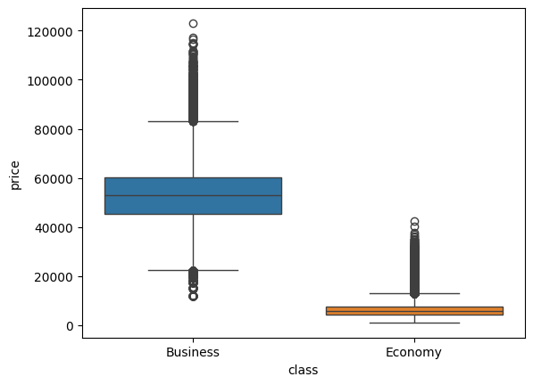

```python
sns.boxplot(data=df,y="price",x="class",hue="class")
plt.show()
```

```python
price_outliers = out(df,"price")
price_outliers.head()
```

|  | date | airline | flight | from | departure_time | stops | destination | arrival_time | class | duration | days_left | price |
| --- | --- | --- | --- | --- | --- | --- | --- | --- | --- | --- | --- | --- |
| 9192 | 2022-02-11 | Vistara | UK-809 | Delhi | Evening | multiple | Kolkata | Afternoon | Business | 21.08 | 1 | 114434.0 |
| 9193 | 2022-02-11 | Vistara | UK-809 | Delhi | Evening | multiple | Kolkata | Afternoon | Business | 21.08 | 1 | 116562.0 |
| 9359 | 2022-02-14 | Vistara | UK-817 | Delhi | Afternoon | multiple | Kolkata | Morning | Business | 17.58 | 4 | 100395.0 |
| 9428 | 2022-02-15 | Vistara | UK-995 | Delhi | Morning | one | Kolkata | Afternoon | Business | 6.50 | 5 | 99129.0 |
| 9429 | 2022-02-15 | Vistara | UK-963 | Delhi | Morning | one | Kolkata | Afternoon | Business | 8.00 | 5 | 101369.0 |

```python
price_outliers["departure_time"].value_counts(normalize=True)
```

```
departure_time
Morning      0.544715
Evening      0.333333
Night        0.065041
Afternoon    0.056911
Name: proportion, dtype: float64
```

```python
price_outliers["stops"].value_counts(normalize=True)
```

```
stops
one         0.772358
multiple    0.227642
Name: proportion, dtype: float64
```

```python
price_outliers["class"].value_counts()
```

[output not shown]

```python
price_outliers["airline"].value_counts()
```

```
airline
Vistara    123
Name: count, dtype: int64
```

## **The outliers in the price column are present primarily because all identified high-priced flights are in the Business class, have either one or multiple stops, are operated exclusively by Vistara, majority are departing in the morning or evening and some are booked close to the departure date, all of which contribute to significantly higher prices.**

- **One of the reason might be due to Business class tickets being significantly more expensive than economy class due to additional amenities, more spacious seating, premium services, and higher levels of comfort.**
- **Vistara, being the sole airline in the outliers dataset, may have higher pricing strategies for certain routes, especially for business class travelers. This could be due to their target market, service quality, and operational costs.**

**So we can't exclude the outliers as they are true outliers.**

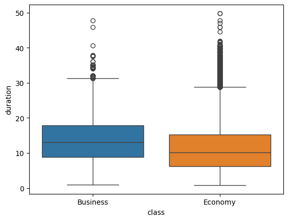

```python
sns.boxplot(data=df,y="duration",x="class",hue="class")
plt.show()
```

```python
duration_outliers = out(df,"duration")
duration_outliers.head()
```

|  | date | airline | flight | from | departure_time | stops | destination | arrival_time | class | duration | days_left | price |
| --- | --- | --- | --- | --- | --- | --- | --- | --- | --- | --- | --- | --- |
| 15011 | 2022-03-28 | Air India | AI-423 | Delhi | Morning | one | Hyderabad | Afternoon | Business | 30.42 | 46 | 47408.0 |
| 27065 | 2022-03-26 | Vistara | UK-621 | Mumbai | Afternoon | one | Bangalore | Evening | Business | 31.08 | 44 | 64005.0 |
| 27150 | 2022-03-27 | Vistara | UK-621 | Mumbai | Afternoon | one | Bangalore | Evening | Business | 31.08 | 45 | 64005.0 |
| 27231 | 2022-03-28 | Vistara | UK-621 | Mumbai | Afternoon | one | Bangalore | Evening | Business | 31.08 | 46 | 64005.0 |
| 27308 | 2022-03-29 | Vistara | UK-621 | Mumbai | Afternoon | one | Bangalore | Evening | Business | 31.08 | 47 | 64005.0 |

```python
duration_outliers.flight.value_counts()
```

```
flight
UK-867    136
UK-706    109
UK-822     99
UK-826     94
AI-763     94
         ...
AI-861      1
AI-877      1
AI-420      1
UK-830      1
AI-539      1
Name: count, Length: 110, dtype: int64
```

```python
df[df["flight"]=="UK-706"].tail()
```

|  | date | airline | flight | from | departure_time | stops | destination | arrival_time | class | duration | days_left | price |
| --- | --- | --- | --- | --- | --- | --- | --- | --- | --- | --- | --- | --- |
| 246067 | 2022-03-31 | Vistara | UK-706 | Kolkata | Morning | one | Chennai | Evening | Economy | 10.00 | 49 | 6009.0 |
| 246095 | 2022-03-31 | Vistara | UK-706 | Kolkata | Morning | one | Chennai | Evening | Economy | 9.67 | 49 | 8589.0 |
| 246097 | 2022-03-31 | Vistara | UK-706 | Kolkata | Morning | multiple | Chennai | Morning | Economy | 22.58 | 49 | 15082.0 |
| 246098 | 2022-03-31 | Vistara | UK-706 | Kolkata | Morning | multiple | Chennai | Morning | Economy | 25.58 | 49 | 15082.0 |
| 246099 | 2022-03-31 | Vistara | UK-706 | Kolkata | Morning | multiple | Chennai | Evening | Economy | 33.67 | 49 | 15082.0 |

```python
df[df["flight"]=="UK-706"]["duration"].mean()
```

```
12.659752704791346
```

```python
df[df["flight"]=="UK-867"]["duration"].mean()
```

```
25.480348837209302
```

```python
df[df["flight"]=="UK-621"]["duration"].mean()
```

```
26.021769911504425
```

## **From the above we can observe that the flight durations contains outliers and these outliers in the flight duration column are valid and likely caused by real-world variations in flight operations, such as the number of stops, specific flight routes, layover times, and the types of aircraft used. So we can't exclude the outliers as they are true outliers.**

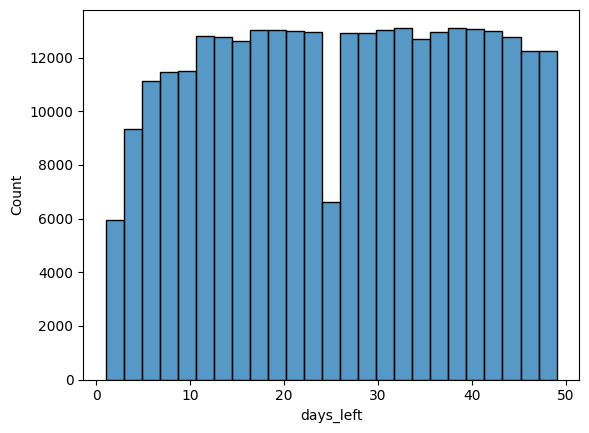

```python
sns.histplot(df["days_left"],bins=25)
plt.show()
```

### **Descriptive Analysis**

```python
pd.crosstab(df['from'], df['destination'])
```

| destination from | Bangalore | Chennai | Delhi | Hyderabad | Kolkata | Mumbai |
| --- | --- | --- | --- | --- | --- | --- |
| Bangalore | 0 | 6410 | 13756 | 8971 | 10029 | 12940 |
| Chennai | 6493 | 0 | 9783 | 6103 | 6983 | 9338 |
| Delhi | 14012 | 10780 | 0 | 9328 | 11934 | 15291 |
| Hyderabad | 7898 | 6395 | 8507 | 0 | 7987 | 10073 |
| Kolkata | 9824 | 6653 | 10506 | 7897 | 0 | 11467 |
| Mumbai | 12885 | 10130 | 14809 | 10477 | 12602 | 0 |

## **From the above we can observe:**

- **The highest no. of flights are flying from `Delhi` to `Mumbai`, this might be beacause they're quite the famous cities also known as `capital` and `financial capital` of india.**
- **The lowest count of flights are from `Chennai` to `Hyderabad`, this might be because of them being close to eachother, leading to the availability of other kinds of transportations.**

```python
df.describe().T
```

|  | count | mean | std | min | 25% | 50% | 75% | max |
| --- | --- | --- | --- | --- | --- | --- | --- | --- |
| duration | 300261.0 | 12.217794 | 7.192961 | 0.83 | 6.75 | 11.25 | 16.17 | 49.83 |
| days_left | 300261.0 | 26.004473 | 13.560985 | 1.00 | 15.00 | 26.00 | 38.00 | 49.00 |
| price | 300261.0 | 20883.717666 | 22695.911266 | 1105.00 | 4783.00 | 7425.00 | 42521.00 | 123071.00 |

```python
df.corr(numeric_only=True).style.background_gradient(cmap='coolwarm')
```

|  | duration | days_left | price |
| --- | --- | --- | --- |
| duration | 1.000000 | -0.039105 | 0.204473 |
| days_left | -0.039105 | 1.000000 | -0.091917 |
| price | 0.204473 | -0.091917 | 1.000000 |

## **Above table shows the correlation of the different numerical columns in our dataset. We can observe that `price` and `duration` have a weak positive relation, also that `price` and `days_left` have a weak negative correlation.**

```python
df.groupby(by=["airline","class"])["price"].mean()
```

```
airline    class
Air India  Business    47131.039212
           Economy      7313.730144
AirAsia    Economy      4091.072742
GO FIRST   Economy      5651.930578
Indigo     Economy      5324.216303
SpiceJet   Economy      6179.278881
StarAir    Economy      4932.655738
Trujet     Economy      3244.634146
Vistara    Business    55477.027777
           Economy      7806.943645
Name: price, dtype: float64
```

```python
df.groupby(by=["from",'destination'])["price"].agg(["min","max","mean","median",np.std])
```

| from | destination | min | max | mean | median | std |
| --- | --- | --- | --- | --- | --- | --- |
| Bangalore | Chennai | 1603.0 | 90720.0 | 23321.850078 | 9241.0 | 22573.185689 |
|  | Delhi | 2723.0 | 111883.0 | 17723.313972 | 7164.0 | 19746.484106 |
|  | Hyderabad | 1694.0 | 83239.0 | 21152.051053 | 7813.0 | 21861.177859 |
|  | Kolkata | 3026.0 | 105168.0 | 23498.234221 | 8112.0 | 24630.560155 |
|  | Mumbai | 2150.0 | 103819.0 | 23127.231376 | 7113.0 | 25887.165127 |
| Chennai | Bangalore | 1443.0 | 107597.0 | 25081.850454 | 10469.0 | 23405.422526 |
|  | Delhi | 2051.0 | 103683.0 | 18981.863948 | 7352.0 | 21946.879653 |
|  | Hyderabad | 1105.0 | 92752.0 | 21591.345404 | 7373.0 | 22866.927328 |
|  | Kolkata | 2359.0 | 104624.0 | 22669.932407 | 8394.0 | 23667.149966 |
|  | Mumbai | 1830.0 | 114704.0 | 22765.849647 | 8233.0 | 25118.401202 |
| Delhi | Bangalore | 3090.0 | 85353.0 | 17880.216315 | 6642.0 | 19904.508234 |
|  | Chennai | 1998.0 | 104466.0 | 19369.881354 | 7425.0 | 22127.553940 |
|  | Hyderabad | 2022.0 | 114507.0 | 17347.288379 | 6109.0 | 18768.239479 |
|  | Kolkata | 2480.0 | 117307.0 | 20566.409418 | 7084.0 | 23655.844456 |
|  | Mumbai | 2281.0 | 95657.0 | 19354.405336 | 7262.0 | 19776.397176 |
| Hyderabad | Bangalore | 1755.0 | 97767.0 | 21245.945429 | 6855.0 | 22174.741408 |
|  | Chennai | 1543.0 | 95208.0 | 21848.065989 | 7702.0 | 22527.946093 |
|  | Delhi | 2200.0 | 86203.0 | 17242.639473 | 6138.0 | 18547.945651 |
|  | Kolkata | 2056.0 | 97381.0 | 20823.893201 | 7767.0 | 22237.613504 |
|  | Mumbai | 2250.0 | 115211.0 | 20065.715179 | 6633.0 | 22633.659515 |
| Kolkata | Bangalore | 3465.0 | 105638.0 | 22744.808428 | 8111.0 | 24130.762785 |
|  | Chennai | 2966.0 | 95183.0 | 23660.361040 | 8589.0 | 23371.419897 |
|  | Delhi | 2994.0 | 123071.0 | 19422.354559 | 6723.0 | 22693.238883 |
|  | Hyderabad | 2436.0 | 114705.0 | 21500.011397 | 8467.0 | 22690.671624 |
|  | Mumbai | 3379.0 | 110936.0 | 22078.883579 | 7958.0 | 23887.604966 |
| Mumbai | Bangalore | 2074.0 | 114523.0 | 23147.873807 | 7192.0 | 25900.493645 |
|  | Chennai | 1890.0 | 111964.0 | 22781.899112 | 8148.0 | 24690.486578 |
|  | Delhi | 2336.0 | 111437.0 | 18725.320008 | 6300.0 | 19493.523862 |
|  | Hyderabad | 2105.0 | 99677.0 | 20992.128567 | 7584.0 | 22807.139498 |
|  | Kolkata | 2835.0 | 100909.0 | 22379.146723 | 7518.0 | 23998.184785 |

## **From the above table we can observe the flight tickets cost with respect to each of the base city to the destination city. It contains the values like "min","max","mean","median" and "Standard deviation" of the price based on the different locations the flight travels between.**

# **Pre-Processing**

```python
import numpy as np
import pandas as pd
import matplotlib.pyplot as plt
import seaborn as sns

df = pd.read_csv("/content/drive/MyDrive/FINAL-PROJECT-ML/flight_data.csv")
df.head()
```

|  | date | airline | flight | from | departure_time | stops | destination | arrival_time | class | duration | days_left | price |
| --- | --- | --- | --- | --- | --- | --- | --- | --- | --- | --- | --- | --- |
| 0 | 2022-02-11 | Air India | AI-868 | Delhi | Evening | zero | Mumbai | Evening | Business | 2.00 | 1 | 25612.0 |
| 1 | 2022-02-11 | Air India | AI-624 | Delhi | Evening | zero | Mumbai | Night | Business | 2.25 | 1 | 25612.0 |
| 2 | 2022-02-11 | Air India | AI-531 | Delhi | Evening | one | Mumbai | Evening | Business | 24.75 | 1 | 42220.0 |
| 3 | 2022-02-11 | Air India | AI-839 | Delhi | Night | one | Mumbai | Night | Business | 26.50 | 1 | 44450.0 |
| 4 | 2022-02-11 | Air India | AI-544 | Delhi | Evening | one | Mumbai | Night | Business | 6.67 | 1 | 46690.0 |

### **dropping the `data` and `flight` as they're are not so important for our models. As we've made other columns which can compensate for the date column and the flight column is similar to id which has a high cardinality.**

```python
df_new = df.drop(columns=["date","flight"])
to_drop = df_new[df_new.duplicated()].index
df_new = df_new.drop(to_drop)
df_new.head()
```

|  | airline | from | departure_time | stops | destination | arrival_time | class | duration | days_left | price |
| --- | --- | --- | --- | --- | --- | --- | --- | --- | --- | --- |
| 0 | Air India | Delhi | Evening | zero | Mumbai | Evening | Business | 2.00 | 1 | 25612.0 |
| 1 | Air India | Delhi | Evening | zero | Mumbai | Night | Business | 2.25 | 1 | 25612.0 |
| 2 | Air India | Delhi | Evening | one | Mumbai | Evening | Business | 24.75 | 1 | 42220.0 |
| 3 | Air India | Delhi | Night | one | Mumbai | Night | Business | 26.50 | 1 | 44450.0 |
| 4 | Air India | Delhi | Evening | one | Mumbai | Night | Business | 6.67 | 1 | 46690.0 |

## **Dropping the `3195` duplicates we've found in the dataset.**

```python
df_new.info()
```

```
<class 'pandas.core.frame.DataFrame'>
Index: 297066 entries, 0 to 300260
Data columns (total 10 columns):
 #   Column          Non-Null Count   Dtype
---  ------          --------------   -----
 0   airline         297066 non-null  object
 1   from            297066 non-null  object
 2   departure_time  297066 non-null  object
 3   stops           297066 non-null  object
 4   destination     297066 non-null  object
 5   arrival_time    297066 non-null  object
 6   class           297066 non-null  object
 7   duration        297066 non-null  float64
 8   days_left       297066 non-null  int64
 9   price           297066 non-null  float64
dtypes: float64(2), int64(1), object(7)
memory usage: 24.9+ MB
```

```python
from sklearn.model_selection import train_test_split

X = df_new.drop(columns=["price"])
y = df_new["price"]

X_train, X_test, y_train, y_test = train_test_split(X, y, test_size=0.2, random_state=49)
```

```python
print(X_train.shape,X_test.shape)
print(y_train.shape,y_test.shape)
```

```
(237652, 9) (59414, 9)
(237652,) (59414,)
```

```python
X_train_cat = X_train.select_dtypes(include="object")
X_train_cat.head()
```

|  | airline | from | departure_time | stops | destination | arrival_time | class |
| --- | --- | --- | --- | --- | --- | --- | --- |
| 199878 | Vistara | Bangalore | Night | one | Kolkata | Morning | Economy |
| 134646 | SpiceJet | Delhi | Evening | one | Chennai | Morning | Economy |
| 64564 | Air India | Kolkata | Afternoon | one | Hyderabad | Morning | Business |
| 286996 | Indigo | Chennai | Evening | one | Mumbai | Morning | Economy |
| 274395 | Vistara | Chennai | Evening | one | Delhi | Morning | Economy |

```python
X_train_num = X_train.select_dtypes(exclude="object")
X_train_num.head()
```

|  | duration | days_left |
| --- | --- | --- |
| 199878 | 12.00 | 27 |
| 134646 | 13.08 | 38 |
| 64564 | 19.00 | 22 |
| 286996 | 10.25 | 46 |
| 274395 | 11.58 | 5 |

```python
!pip install category_encoders
```

```
     ━━━━━━━━━━━━━━━━━━━━━━━━━━━━━━━━━━━━━━━━ 81.9/81.9 kB 1.0 MB/s eta 0:00:00
```

```python
from sklearn.preprocessing import OneHotEncoder, RobustScaler
from category_encoders import BinaryEncoder

ohe = OneHotEncoder(drop = "first",sparse_output=False)
rs = RobustScaler()
be = BinaryEncoder()
```

```python
X_train_cat_trans = pd.DataFrame(be.fit_transform(X_train_cat),
                             columns = be.get_feature_names_out(X_train_cat.columns),
                             index = X_train_cat.index)
X_train_cat_trans.head()
```

|  | airline_0 | airline_1 | airline_2 | airline_3 | from_0 | from_1 | from_2 | departure_time_0 | departure_time_1 | departure_time_2 | stops_0 | stops_1 | destination_0 | destination_1 | destination_2 | arrival_time_0 | arrival_time_1 | arrival_time_2 | class_0 | class_1 |
| --- | --- | --- | --- | --- | --- | --- | --- | --- | --- | --- | --- | --- | --- | --- | --- | --- | --- | --- | --- | --- |
| 199878 | 0 | 0 | 0 | 1 | 0 | 0 | 1 | 0 | 0 | 1 | 0 | 1 | 0 | 0 | 1 | 0 | 0 | 1 | 0 | 1 |
| 134646 | 0 | 0 | 1 | 0 | 0 | 1 | 0 | 0 | 1 | 0 | 0 | 1 | 0 | 1 | 0 | 0 | 0 | 1 | 0 | 1 |
| 64564 | 0 | 0 | 1 | 1 | 0 | 1 | 1 | 0 | 1 | 1 | 0 | 1 | 0 | 1 | 1 | 0 | 0 | 1 | 1 | 0 |
| 286996 | 0 | 1 | 0 | 0 | 1 | 0 | 0 | 0 | 1 | 0 | 0 | 1 | 1 | 0 | 0 | 0 | 0 | 1 | 0 | 1 |
| 274395 | 0 | 0 | 0 | 1 | 1 | 0 | 0 | 0 | 1 | 0 | 0 | 1 | 1 | 0 | 1 | 0 | 0 | 1 | 0 | 1 |

## **Robust Scaling : Since there exists true otuliers in my data. I've used Robust Scaling to scale them down to a similar scale.**

```python
X_train_num_trans = pd.DataFrame(rs.fit_transform(X_train_num),
                             columns = X_train_num.columns,
                             index = X_train_num.index)
X_train_num_trans.head()
```

|  | duration | days_left |
| --- | --- | --- |
| 199878 | 0.072432 | 0.043478 |
| 134646 | 0.189189 | 0.521739 |
| 64564 | 0.829189 | -0.173913 |
| 286996 | -0.116757 | 0.869565 |
| 274395 | 0.027027 | -0.913043 |

```python
X_train_transformed = pd.concat([X_train_cat_trans,X_train_num_trans],axis=1)
X_train_transformed.head()
```

|  | airline_0 | airline_1 | airline_2 | airline_3 | from_0 | from_1 | from_2 | departure_time_0 | departure_time_1 | departure_time_2 | ... | destination_0 | destination_1 | destination_2 | arrival_time_0 | arrival_time_1 | arrival_time_2 | class_0 | class_1 | duration | days_left |
| --- | --- | --- | --- | --- | --- | --- | --- | --- | --- | --- | --- | --- | --- | --- | --- | --- | --- | --- | --- | --- | --- |
| 199878 | 0 | 0 | 0 | 1 | 0 | 0 | 1 | 0 | 0 | 1 | ... | 0 | 0 | 1 | 0 | 0 | 1 | 0 | 1 | 0.072432 | 0.043478 |
| 134646 | 0 | 0 | 1 | 0 | 0 | 1 | 0 | 0 | 1 | 0 | ... | 0 | 1 | 0 | 0 | 0 | 1 | 0 | 1 | 0.189189 | 0.521739 |
| 64564 | 0 | 0 | 1 | 1 | 0 | 1 | 1 | 0 | 1 | 1 | ... | 0 | 1 | 1 | 0 | 0 | 1 | 1 | 0 | 0.829189 | -0.173913 |
| 286996 | 0 | 1 | 0 | 0 | 1 | 0 | 0 | 0 | 1 | 0 | ... | 1 | 0 | 0 | 0 | 0 | 1 | 0 | 1 | -0.116757 | 0.869565 |
| 274395 | 0 | 0 | 0 | 1 | 1 | 0 | 0 | 0 | 1 | 0 | ... | 1 | 0 | 1 | 0 | 0 | 1 | 0 | 1 | 0.027027 | -0.913043 |

5 rows × 22 columns

## **Feature Engineering - Feature Selection**

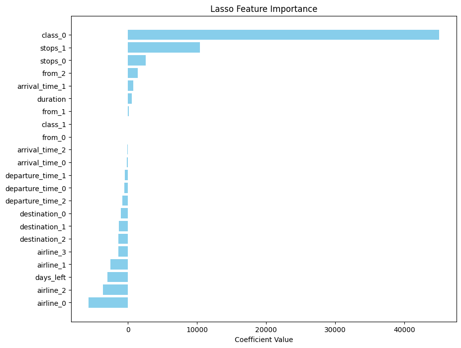

```python
from sklearn.linear_model import Lasso

lasso = Lasso(alpha=0.1)
lasso_model = lasso.fit(X_train_transformed,y_train)

feature_names = X_train_transformed.columns
coef = lasso_model.coef_

importance_df = pd.DataFrame({'Feature': feature_names, 'Importance': coef})
importance_df = importance_df.sort_values(by='Importance', ascending=False)

# Plot the feature importance
plt.figure(figsize=(10, 8))
plt.barh(importance_df['Feature'], importance_df['Importance'], color='skyblue')
plt.xlabel('Coefficient Value')
plt.title('Lasso Feature Importance')
plt.gca().invert_yaxis()
plt.show()
```

```python
pd.DataFrame(lasso_model.coef_,X_train_transformed.columns,columns=['importance']).sort_values(by='importance',ascending=False)
```

|  | importance |
| --- | --- |
| class_0 | 45020.580397 |
| stops_1 | 10391.761764 |
| stops_0 | 2533.848481 |
| from_2 | 1392.893466 |
| arrival_time_1 | 732.126352 |
| duration | 522.936097 |
| from_1 | 133.886106 |
| class_1 | -0.000000 |
| from_0 | -26.519470 |
| arrival_time_2 | -88.992082 |
| arrival_time_0 | -139.168301 |
| departure_time_1 | -452.866444 |
| departure_time_0 | -496.161970 |
| departure_time_2 | -831.831156 |
| destination_0 | -1034.958554 |
| destination_1 | -1342.556719 |
| destination_2 | -1393.859366 |
| airline_3 | -1405.880758 |
| airline_1 | -2556.307480 |
| days_left | -2981.037813 |
| airline_2 | -3645.038790 |
| airline_0 | -5707.264430 |

```python
from sklearn.tree import DecisionTreeRegressor, plot_tree

dt = DecisionTreeRegressor(max_depth=4,random_state=25)
dt_model = dt.fit(X_train_transformed,y_train)
```

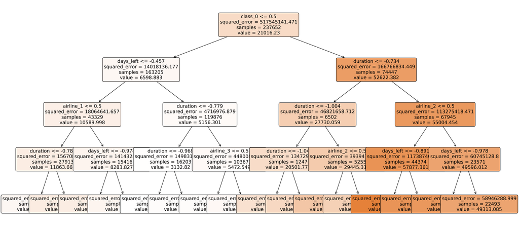

```python
plt.figure(figsize=(25,12),dpi=300)

f = plot_tree(dt_model,
           feature_names= X_train_transformed.columns,
           filled=True,
           rounded=True,
           fontsize=14)
plt.show()
```

```python
pd.DataFrame(dt_model.feature_importances_,X_train_transformed.columns,columns=['importance']).sort_values(by='importance',ascending=False)
```

|  | importance |
| --- | --- |
| class_0 | 0.937705 |
| duration | 0.040334 |
| days_left | 0.010874 |
| airline_2 | 0.009459 |
| airline_1 | 0.001102 |
| airline_3 | 0.000526 |
| destination_1 | 0.000000 |
| class_1 | 0.000000 |
| arrival_time_2 | 0.000000 |
| arrival_time_1 | 0.000000 |
| arrival_time_0 | 0.000000 |
| destination_2 | 0.000000 |
| airline_0 | 0.000000 |
| destination_0 | 0.000000 |
| stops_0 | 0.000000 |
| departure_time_2 | 0.000000 |
| departure_time_1 | 0.000000 |
| departure_time_0 | 0.000000 |
| from_2 | 0.000000 |
| from_1 | 0.000000 |
| from_0 | 0.000000 |
| stops_1 | 0.000000 |

```python
from sklearn.ensemble import RandomForestRegressor

rf = RandomForestRegressor(max_depth=4,random_state=25)
rf_model = rf.fit(X_train_transformed,y_train)
```

```python
pd.DataFrame(rf_model.feature_importances_,X_train_transformed.columns,columns=['importance']).sort_values(by='importance',ascending=False).head(15)
```

|  | importance |
| --- | --- |
| class_1 | 0.496940 |
| class_0 | 0.440698 |
| duration | 0.040465 |
| days_left | 0.010779 |
| airline_2 | 0.009464 |
| airline_1 | 0.001101 |
| airline_3 | 0.000540 |
| from_2 | 0.000013 |
| destination_1 | 0.000000 |
| arrival_time_2 | 0.000000 |
| arrival_time_1 | 0.000000 |
| arrival_time_0 | 0.000000 |
| destination_2 | 0.000000 |
| airline_0 | 0.000000 |
| destination_0 | 0.000000 |

## **From the above observations, we can identify few of the important features for our prediction.**

- `class` , `durations` , `days_left` , `stops` and `airline`

### **Seggregating the important features.**

```python
df_new = df.drop(columns=["date","flight"])
to_drop = df_new[df_new.duplicated()].index
df_new = df_new.drop(to_drop)
df_new.head()
```

|  | airline | from | departure_time | stops | destination | arrival_time | class | duration | days_left | price |
| --- | --- | --- | --- | --- | --- | --- | --- | --- | --- | --- |
| 0 | Air India | Delhi | Evening | zero | Mumbai | Evening | Business | 2.00 | 1 | 25612.0 |
| 1 | Air India | Delhi | Evening | zero | Mumbai | Night | Business | 2.25 | 1 | 25612.0 |
| 2 | Air India | Delhi | Evening | one | Mumbai | Evening | Business | 24.75 | 1 | 42220.0 |
| 3 | Air India | Delhi | Night | one | Mumbai | Night | Business | 26.50 | 1 | 44450.0 |
| 4 | Air India | Delhi | Evening | one | Mumbai | Night | Business | 6.67 | 1 | 46690.0 |

```python
dfc = df_new.copy()
dfc.head()
```

|  | airline | from | departure_time | stops | destination | arrival_time | class | duration | days_left | price |
| --- | --- | --- | --- | --- | --- | --- | --- | --- | --- | --- |
| 0 | Air India | Delhi | Evening | zero | Mumbai | Evening | Business | 2.00 | 1 | 25612.0 |
| 1 | Air India | Delhi | Evening | zero | Mumbai | Night | Business | 2.25 | 1 | 25612.0 |
| 2 | Air India | Delhi | Evening | one | Mumbai | Evening | Business | 24.75 | 1 | 42220.0 |
| 3 | Air India | Delhi | Night | one | Mumbai | Night | Business | 26.50 | 1 | 44450.0 |
| 4 | Air India | Delhi | Evening | one | Mumbai | Night | Business | 6.67 | 1 | 46690.0 |

```python
dfc = dfc[["airline","class","duration","days_left","stops","price"]]
dfc.head()
```

|  | airline | class | duration | days_left | stops | price |
| --- | --- | --- | --- | --- | --- | --- |
| 0 | Air India | Business | 2.00 | 1 | zero | 25612.0 |
| 1 | Air India | Business | 2.25 | 1 | zero | 25612.0 |
| 2 | Air India | Business | 24.75 | 1 | one | 42220.0 |
| 3 | Air India | Business | 26.50 | 1 | one | 44450.0 |
| 4 | Air India | Business | 6.67 | 1 | one | 46690.0 |

```python
dfc.to_csv("/content/drive/MyDrive/FINAL-PROJECT-ML/df_feat.csv",index=False)
```

```python
import pandas as pd
import numpy as np

dfc = pd.read_csv("/content/drive/MyDrive/FINAL-PROJECT-ML/df_feat.csv")
dfc.head()
```

|  | airline | class | duration | days_left | stops | price |
| --- | --- | --- | --- | --- | --- | --- |
| 0 | Air India | Business | 2.00 | 1 | zero | 25612.0 |
| 1 | Air India | Business | 2.25 | 1 | zero | 25612.0 |
| 2 | Air India | Business | 24.75 | 1 | one | 42220.0 |
| 3 | Air India | Business | 26.50 | 1 | one | 44450.0 |
| 4 | Air India | Business | 6.67 | 1 | one | 46690.0 |

```python
dfc.shape
```

```
(297066, 6)
```

```python
df_samp = dfc.sample(n=60000,random_state=49)
df_samp.shape
```

```
(60000, 6)
```

```python
from sklearn.model_selection import train_test_split

X_feat = df_samp.drop(columns=["price"])
y_feat = df_samp["price"]

X_feat_train, X_feat_test, y_feat_train, y_feat_test = train_test_split(X_feat, y_feat, test_size=0.25, random_state=49)
```

```python
print(X_feat_train.shape,X_feat_test.shape)
print(y_feat_train.shape,y_feat_test.shape)
```

```
(45000, 5) (15000, 5)
(45000,) (15000,)
```

## **Pre-Processing on Feature Selected Dataset**

```python
!pip install category_encoders
```

```
     ━━━━━━━━━━━━━━━━━━━━━━━━━━━━━━━━━━━━━━━━ 81.9/81.9 kB 863.5 kB/s eta 0:00:00
```

```python
from sklearn.preprocessing import OneHotEncoder, RobustScaler
from category_encoders import BinaryEncoder

ohe = OneHotEncoder(drop = "first",sparse_output=False)
rs = RobustScaler()
be = BinaryEncoder()
```

```python
X_feat_train_cat = X_feat_train.select_dtypes(include="object")
X_feat_train_num = X_feat_train.select_dtypes(exclude="object")
```

```python
X_feat_train_cat_trans = pd.DataFrame(be.fit_transform(X_feat_train_cat),
                             columns = be.get_feature_names_out(X_feat_train_cat.columns),
                             index = X_feat_train_cat.index)

X_feat_train_num_trans = pd.DataFrame(rs.fit_transform(X_feat_train_num),
                             columns = X_feat_train_num.columns,
                             index = X_feat_train_num.index)

X_feat_train_transformed = pd.concat([X_feat_train_cat_trans,X_feat_train_num_trans],axis=1)
X_feat_train_transformed.head()
```

|  | airline_0 | airline_1 | airline_2 | airline_3 | class_0 | class_1 | stops_0 | stops_1 | duration | days_left |
| --- | --- | --- | --- | --- | --- | --- | --- | --- | --- | --- |
| 67933 | 0 | 0 | 0 | 1 | 0 | 1 | 0 | 1 | -0.476757 | -0.782609 |
| 275606 | 0 | 0 | 1 | 0 | 1 | 0 | 0 | 1 | -0.008649 | 0.347826 |
| 161763 | 0 | 0 | 1 | 1 | 1 | 0 | 0 | 1 | 0.820541 | 1.000000 |
| 98697 | 0 | 0 | 1 | 1 | 1 | 0 | 0 | 1 | -0.432432 | 0.173913 |
| 236846 | 0 | 0 | 1 | 1 | 1 | 0 | 0 | 1 | -0.638919 | 0.260870 |

```python
X_feat_test_cat = X_feat_test.select_dtypes(include="object")
X_feat_test_num = X_feat_test.select_dtypes(exclude="object")
```

```python
X_feat_test_cat_trans = pd.DataFrame(be.transform(X_feat_test_cat),
                             columns = be.get_feature_names_out(X_feat_test_cat.columns),
                             index = X_feat_test_cat.index)

X_feat_test_num_trans = pd.DataFrame(rs.transform(X_feat_test_num),
                             columns = X_feat_test_num.columns,
                             index = X_feat_test_num.index)

X_feat_test_transformed = pd.concat([X_feat_test_cat_trans,X_feat_test_num_trans],axis=1)
X_feat_test_transformed.head()
```

|  | airline_0 | airline_1 | airline_2 | airline_3 | class_0 | class_1 | stops_0 | stops_1 | duration | days_left |
| --- | --- | --- | --- | --- | --- | --- | --- | --- | --- | --- |
| 157594 | 0 | 1 | 1 | 0 | 1 | 0 | 0 | 1 | 0.261622 | 0.000000 |
| 97118 | 0 | 0 | 1 | 1 | 1 | 0 | 1 | 0 | -0.990270 | -0.130435 |
| 178347 | 0 | 0 | 1 | 1 | 1 | 0 | 0 | 1 | -0.324324 | -0.434783 |
| 37440 | 0 | 0 | 0 | 1 | 0 | 1 | 0 | 1 | -0.405405 | 0.695652 |
| 63249 | 0 | 0 | 1 | 1 | 0 | 1 | 0 | 1 | -0.162162 | -0.956522 |

## **MODEL BUILDING**

```python
from sklearn.tree import DecisionTreeRegressor
from sklearn.neighbors import KNeighborsRegressor

from sklearn.linear_model import LinearRegression
from sklearn.linear_model import RANSACRegressor
from sklearn.linear_model import TheilSenRegressor
from sklearn.linear_model import HuberRegressor
from sklearn.linear_model import Lasso
from sklearn.linear_model import Ridge
from sklearn.linear_model import ElasticNet

import xgboost as xgb
from xgboost import XGBRegressor
from sklearn.ensemble import GradientBoostingRegressor
from sklearn.ensemble import AdaBoostRegressor
from sklearn.ensemble import RandomForestRegressor

from sklearn.metrics import mean_absolute_error, mean_squared_error, r2_score
from sklearn.model_selection import cross_val_score
```

```python
n = len(y_feat_test)
p = X_feat.shape[1]

def adj_r2(x):
  return 1 - (1 - x) * (n - 1) / (n - p - 1)
```

## **Basic Models**

```python
KNN = KNeighborsRegressor()
DT = DecisionTreeRegressor()

LS = LinearRegression()
LS_RANSAC = RANSACRegressor()
LS_TheilSen = TheilSenRegressor()
LS_Huber = HuberRegressor()
LS_Lasso = Lasso()
LS_Ridge = Ridge()
LS_ElasticNet = ElasticNet()

RF = RandomForestRegressor()
GB = GradientBoostingRegressor()
XGB = XGBRegressor()
ADA = AdaBoostRegressor()
```

#### **KNeighbours Model**

```python
KNN.fit(X_feat_train_transformed,y_feat_train)
y_test_pred_knn = KNN.predict(X_feat_test_transformed)

print(mean_absolute_error(y_feat_test,y_test_pred_knn))
print(mean_squared_error(y_feat_test,y_test_pred_knn))
print(np.sqrt(mean_squared_error(y_feat_test,y_test_pred_knn)))
print(r2_score(y_feat_test,y_test_pred_knn))
print(adj_r2(r2_score(y_feat_test,y_test_pred_knn)))
```

```
3427.560053333333
34866384.942928
5904.776451562582
0.9337417379821193
0.9337196430568099
```

```python
models = [KNN,DT,LS,LS_RANSAC,LS_TheilSen,LS_Huber,LS_Lasso,LS_Ridge,LS_ElasticNet,RF,GB,XGB,ADA]
TRAIN_MAE = []
TRAIN_MSE = []
TRAIN_RMSE = []
TRAIN_R2 = []
TRAIN_ADJ_R2 = []
MAE = []
MSE = []
RMSE = []
R2 = []
Adj_R2 = []

for i in models:
  i.fit(X_feat_train_transformed,y_feat_train)
  y_train_pred = i.predict(X_feat_train_transformed)
  y_test_pred = i.predict(X_feat_test_transformed)
  TRAIN_MAE.append(round(mean_absolute_error(y_feat_train,y_train_pred),2))
  TRAIN_MSE.append(round(mean_squared_error(y_feat_train,y_train_pred),2))
  TRAIN_RMSE.append(round(np.sqrt(mean_squared_error(y_feat_train,y_train_pred)),2))
  TRAIN_R2.append(round(r2_score(y_feat_train,y_train_pred),2))
  TRAIN_ADJ_R2.append(round(adj_r2(r2_score(y_feat_train,y_train_pred)),2))
  MAE.append(round(mean_absolute_error(y_feat_test,y_test_pred),2))
  MSE.append(round(mean_squared_error(y_feat_test,y_test_pred),2))
  RMSE.append(round(np.sqrt(mean_squared_error(y_feat_test,y_test_pred)),2))
  R2.append(round(r2_score(y_feat_test,y_test_pred),2))
  Adj_R2.append(round(adj_r2(r2_score(y_feat_test,y_test_pred)),2))
```

```python
model_names = ["KNeighbours","DecisionTree","LinearRegression","RANSAC","TheilSen","HuberRegressor","Lasso","Ridge","Elastic Net","RandomForest","GradientBoosting","XGBoost","AdaBoost"]
```

```python
pd.DataFrame({"Model":model_names,
              "Train MAE":TRAIN_MAE,
              "Train MSE":TRAIN_MSE,
              "Train RMSE":TRAIN_RMSE,
              "Train R2":TRAIN_R2,
              "Train Adj R2":TRAIN_ADJ_R2,
              "Test MAE":MAE,
              "Test MSE":MSE,
              "Test RMSE":RMSE,
              "Test R2":R2,
              "Test Adj R2":Adj_R2})
```

|  | Model | Train MAE | Train MSE | Train RMSE | Train R2 | Train Adj R2 | Test MAE | Test MSE | Test RMSE | Test R2 | Test Adj R2 |
| --- | --- | --- | --- | --- | --- | --- | --- | --- | --- | --- | --- |
| 0 | KNeighbours | 2791.82 | 2.282446e+07 | 4777.50 | 0.96 | 0.96 | 3427.56 | 3.486638e+07 | 5904.78 | 0.93 | 0.93 |
| 1 | DecisionTree | 1033.68 | 7.524408e+06 | 2743.07 | 0.99 | 0.99 | 3874.28 | 4.919238e+07 | 7013.73 | 0.91 | 0.91 |
| 2 | LinearRegression | 4592.36 | 4.840901e+07 | 6957.66 | 0.91 | 0.91 | 4594.61 | 4.942279e+07 | 7030.13 | 0.91 | 0.91 |
| 3 | RANSAC | 4544.57 | 6.181070e+07 | 7861.98 | 0.88 | 0.88 | 4561.98 | 6.266586e+07 | 7916.18 | 0.88 | 0.88 |
| 4 | TheilSen | 4477.81 | 4.908197e+07 | 7005.85 | 0.90 | 0.90 | 4491.58 | 5.018490e+07 | 7084.13 | 0.90 | 0.90 |
| 5 | HuberRegressor | 4270.72 | 5.146298e+07 | 7173.77 | 0.90 | 0.90 | 4288.27 | 5.270245e+07 | 7259.65 | 0.90 | 0.90 |
| 6 | Lasso | 4593.04 | 4.841315e+07 | 6957.96 | 0.91 | 0.91 | 4596.02 | 4.943457e+07 | 7030.97 | 0.91 | 0.91 |
| 7 | Ridge | 4593.41 | 4.840885e+07 | 6957.65 | 0.91 | 0.91 | 4595.61 | 4.942565e+07 | 7030.34 | 0.91 | 0.91 |
| 8 | Elastic Net | 10524.03 | 1.726754e+08 | 13140.60 | 0.66 | 0.66 | 10685.08 | 1.783025e+08 | 13353.00 | 0.66 | 0.66 |
| 9 | RandomForest | 1679.38 | 9.889437e+06 | 3144.75 | 0.98 | 0.98 | 3341.12 | 3.489048e+07 | 5906.82 | 0.93 | 0.93 |
| 10 | GradientBoosting | 3175.06 | 2.908620e+07 | 5393.16 | 0.94 | 0.94 | 3196.00 | 2.953398e+07 | 5434.52 | 0.94 | 0.94 |
| 11 | XGBoost | 2779.56 | 2.248794e+07 | 4742.14 | 0.96 | 0.96 | 3059.90 | 2.803432e+07 | 5294.74 | 0.95 | 0.95 |
| 12 | AdaBoost | 3726.34 | 3.482383e+07 | 5901.17 | 0.93 | 0.93 | 3737.32 | 3.536257e+07 | 5946.64 | 0.93 | 0.93 |

## **HYPER-PARAMETER TUNING**

```python
models = {
    'KNN': (KNeighborsRegressor(),
            {'n_neighbors': list(range(2, 31)), 'weights': ['uniform', 'distance']}),

    'DT': (DecisionTreeRegressor(),
           {'max_depth': list(range(1,50,5))}),

    'LS': (LinearRegression(),
           {}),

    'LS_RANSAC': (RANSACRegressor(),
                  {}),

    'LS_TheilSen': (TheilSenRegressor(),
                    {}),

    'LS_Huber': (HuberRegressor(),
                 {}),

    'LS_Lasso': (Lasso(),
                 {'alpha': [0.01, 0.1, 1, 10, 100]
                  }),

    'LS_Ridge': (Ridge(),
                 {'alpha': [0.01, 0.1, 1, 10, 100]
                  }),

    'RF': (RandomForestRegressor(),
           {'n_estimators': list(range(50, 200)),
            'max_depth': [None, 10, 20, 30, 40, 50]}),

    'GB': (GradientBoostingRegressor(),
           {'n_estimators': list(range(50, 200)),
            'max_depth': [3, 4, 5, 6, None]}),

    'XGB': (XGBRegressor(),
            {'n_estimators': list(range(50, 200)),
             'max_depth': [3, 4, 5, 6, 8, 10],
             'learning_rate': [0.01,0.1,0.15,0.3]}),

    'ADA': (AdaBoostRegressor(),
            {'n_estimators': list(range(50, 200)),
             'learning_rate': [0.01,0.1,0.15,0.3]})

}
```

```python
best_models = dict()
```

```python
from sklearn.model_selection import RandomizedSearchCV

best_model = None
best_score = -float('inf')  # Initialize with a very low value

for model_name, (model, param_grid) in models.items():
    print(f"Training {model_name}...")
    random_search = RandomizedSearchCV(estimator=model,
                                       param_distributions=param_grid,
                                       n_iter=10,
                                       scoring='r2',
                                       cv=5,
                                       random_state=46)
    random_search.fit(X_feat_train_transformed,y_feat_train)

    # Print the best parameters and score for the current model
    print(f"Best {model_name} parameters: {random_search.best_params_}")
    print(f"Best {model_name} score: {random_search.best_score_}")
    best_models[model_name] = random_search.best_estimator_
    print(best_models)

    # Check if this model is better than the current best one
    if random_search.best_score_ > best_score:
        best_score = random_search.best_score_
        best_model = random_search.best_estimator_

print(f"\nBest Model: {best_model}")
print(f"Best Score: {best_score}")
```

```
Training KNN...
Best KNN parameters: {'weights': 'uniform', 'n_neighbors': 29}
Best KNN score: 0.9402252919334328
{'KNN': KNeighborsRegressor(n_neighbors=29)}
Training DT...
Best DT parameters: {'max_depth': 11}
Best DT score: 0.9411041656716719
{'KNN': KNeighborsRegressor(n_neighbors=29), 'DT': DecisionTreeRegressor(max_depth=11)}
Training LS...
Best LS parameters: {}
Best LS score: 0.9058076769789256
{'KNN': KNeighborsRegressor(n_neighbors=29), 'DT': DecisionTreeRegressor(max_depth=11), 'LS': LinearRegression()}
Training LS_RANSAC...
```

```
Best LS_RANSAC parameters: {}
Best LS_RANSAC score: 0.892019533195145
{'KNN': KNeighborsRegressor(n_neighbors=29), 'DT': DecisionTreeRegressor(max_depth=11), 'LS': LinearRegression(), 'LS_RANSAC': RANSACRegressor()}
Training LS_TheilSen...
```

```
Best LS_TheilSen parameters: {}
Best LS_TheilSen score: 0.9045371317618407
{'KNN': KNeighborsRegressor(n_neighbors=29), 'DT': DecisionTreeRegressor(max_depth=11), 'LS': LinearRegression(), 'LS_RANSAC': RANSACRegressor(), 'LS_TheilSen': TheilSenRegressor()}
Training LS_Huber...
```

```
Best LS_Huber parameters: {}
Best LS_Huber score: 0.8998889404895623
{'KNN': KNeighborsRegressor(n_neighbors=29), 'DT': DecisionTreeRegressor(max_depth=11), 'LS': LinearRegression(), 'LS_RANSAC': RANSACRegressor(), 'LS_TheilSen': TheilSenRegressor(), 'LS_Huber': HuberRegressor()}
Training LS_Lasso...
```

```
Best LS_Lasso parameters: {'alpha': 0.01}
Best LS_Lasso score: 0.9058149411131268
{'KNN': KNeighborsRegressor(n_neighbors=29), 'DT': DecisionTreeRegressor(max_depth=11), 'LS': LinearRegression(), 'LS_RANSAC': RANSACRegressor(), 'LS_TheilSen': TheilSenRegressor(), 'LS_Huber': HuberRegressor(), 'LS_Lasso': Lasso(alpha=0.01)}
Training LS_Ridge...
```

```
Best LS_Ridge parameters: {'alpha': 0.1}
Best LS_Ridge score: 0.9058149483505125
{'KNN': KNeighborsRegressor(n_neighbors=29), 'DT': DecisionTreeRegressor(max_depth=11), 'LS': LinearRegression(), 'LS_RANSAC': RANSACRegressor(), 'LS_TheilSen': TheilSenRegressor(), 'LS_Huber': HuberRegressor(), 'LS_Lasso': Lasso(alpha=0.01), 'LS_Ridge': Ridge(alpha=0.1)}
Training RF...
Best RF parameters: {'n_estimators': 79, 'max_depth': 10}
Best RF score: 0.9443993584059115
{'KNN': KNeighborsRegressor(n_neighbors=29), 'DT': DecisionTreeRegressor(max_depth=11), 'LS': LinearRegression(), 'LS_RANSAC': RANSACRegressor(), 'LS_TheilSen': TheilSenRegressor(), 'LS_Huber': HuberRegressor(), 'LS_Lasso': Lasso(alpha=0.01), 'LS_Ridge': Ridge(alpha=0.1), 'RF': RandomForestRegressor…
Training GB...
Best GB parameters: {'n_estimators': 160, 'max_depth': 6}
Best GB score: 0.9474358907823461
{'KNN': KNeighborsRegressor(n_neighbors=29), 'DT': DecisionTreeRegressor(max_depth=11), 'LS': LinearRegression(), 'LS_RANSAC': RANSACRegressor(), 'LS_TheilSen': TheilSenRegressor(), 'LS_Huber': HuberRegressor(), 'LS_Lasso': Lasso(alpha=0.01), 'LS_Ridge': Ridge(alpha=0.1), 'RF': RandomForestRegressor…
Training XGB...
Best XGB parameters: {'n_estimators': 74, 'max_depth': 5, 'learning_rate': 0.3}
Best XGB score: 0.9466038716941159
{'KNN': KNeighborsRegressor(n_neighbors=29), 'DT': DecisionTreeRegressor(max_depth=11), 'LS': LinearRegression(), 'LS_RANSAC': RANSACRegressor(), 'LS_TheilSen': TheilSenRegressor(), 'LS_Huber': HuberRegressor(), 'LS_Lasso': Lasso(alpha=0.01), 'LS_Ridge': Ridge(alpha=0.1), 'RF': RandomForestRegressor…
             colsample_bylevel=None, colsample_bynode=None,
             colsample_bytree=None, device=None, early_stopping_rounds=None,
             enable_categorical=False, eval_metric=None, feature_types=None,
             gamma=None, grow_policy=None, importance_type=None,
             interaction_constraints=None, learning_rate=0.3, max_bin=None,
             max_cat_threshold=None, max_cat_to_onehot=None,
             max_delta_step=None, max_depth=5, max_leaves=None,
             min_child_weight=None, missing=nan, monotone_constraints=None,
             multi_strategy=None, n_estimators=74, n_jobs=None,
             num_parallel_tree=None, random_state=None, ...)}
Training ADA...
Best ADA parameters: {'n_estimators': 79, 'learning_rate': 0.1}
Best ADA score: 0.9330510978783032
{'KNN': KNeighborsRegressor(n_neighbors=29), 'DT': DecisionTreeRegressor(max_depth=11), 'LS': LinearRegression(), 'LS_RANSAC': RANSACRegressor(), 'LS_TheilSen': TheilSenRegressor(), 'LS_Huber': HuberRegressor(), 'LS_Lasso': Lasso(alpha=0.01), 'LS_Ridge': Ridge(alpha=0.1), 'RF': RandomForestRegressor…
             colsample_bylevel=None, colsample_bynode=None,
             colsample_bytree=None, device=None, early_stopping_rounds=None,
             enable_categorical=False, eval_metric=None, feature_types=None,
             gamma=None, grow_policy=None, importance_type=None,
             interaction_constraints=None, learning_rate=0.3, max_bin=None,
             max_cat_threshold=None, max_cat_to_onehot=None,
             max_delta_step=None, max_depth=5, max_leaves=None,
             min_child_weight=None, missing=nan, monotone_constraints=None,
             multi_strategy=None, n_estimators=74, n_jobs=None,
             num_parallel_tree=None, random_state=None, ...), 'ADA': AdaBoostRegressor(learning_rate=0.1, n_estimators=79)}

Best Model: GradientBoostingRegressor(max_depth=6, n_estimators=160)
Best Score: 0.9474358907823461
```

```python
pd.DataFrame({"model":[i for i in best_models.keys()],"parameters":[i for i in best_models.values()]})
```

|  | model | parameters |
| --- | --- | --- |
| 0 | KNN | KNeighborsRegressor(n_neighbors=29) |
| 1 | DT | DecisionTreeRegressor(max_depth=11) |
| 2 | LS | LinearRegression() |
| 3 | LS_RANSAC | RANSACRegressor() |
| 4 | LS_TheilSen | TheilSenRegressor() |
| 5 | LS_Huber | HuberRegressor() |
| 6 | LS_Lasso | Lasso(alpha=0.01) |
| 7 | LS_Ridge | Ridge(alpha=0.1) |
| 8 | RF | (DecisionTreeRegressor(max_depth=10, max_featu... |
| 9 | GB | ([DecisionTreeRegressor(criterion='friedman_ms... |
| 10 | XGB | XGBRegressor(base_score=None, booster=None, ca... |
| 11 | ADA | (DecisionTreeRegressor(max_depth=3, random_sta... |

## **Best Parameters For All Models after Hyper-Parameter Tuning**

```python
import time
tuned_models = [KNeighborsRegressor(n_neighbors=29), DecisionTreeRegressor(max_depth=11),
                LinearRegression(), RANSACRegressor(), TheilSenRegressor(), HuberRegressor(),
                Lasso(alpha=0.01), Ridge(alpha=0.1), RandomForestRegressor(max_depth=10, n_estimators=79),
                GradientBoostingRegressor(max_depth=6, n_estimators=160), XGBRegressor(max_depth=5, n_estimators=74, learning_rate=0.3),
                AdaBoostRegressor(learning_rate=0.1, n_estimators=79)
             ]

model_names = ["KNeighbours","DecisionTree",
               "LinearRegression","RANSAC","TheilSen","HuberRegressor",
               "Lasso","Ridge","RandomForest","GradientBoosting","XGBoost","AdaBoost"]

r2_score_fm = []
adj_r2_score_fm = []
training_time = []
testing_time = []
```

```python
i = 0
for final_model in tuned_models:
    start_train = time.time()
    final_model.fit(X_feat_train_transformed,y_feat_train)
    end_train = time.time()
    training_time.append(end_train - start_train)
    print("model:",model_names[i])
    print(f"Training time: {end_train - start_train} seconds")
    print("-"*50)

    start_test = time.time()
    y_test_pred_fm = final_model.predict(X_feat_test_transformed)
    end_test = time.time()
    testing_time.append(end_test - start_test)
    print(f"Testing time: {end_test - start_test} seconds")
    print("*"*50)

    r2_score_fm.append(round(r2_score(y_feat_test,y_test_pred_fm),2))
    adj_r2_score_fm.append(round(adj_r2(r2_score(y_feat_test,y_test_pred_fm)),2))

    i += 1
```

```
model: KNeighbours
Training time: 0.07761049270629883 seconds
--------------------------------------------------
Testing time: 1.048659086227417 seconds
model: DecisionTree
Training time: 0.07290387153625488 seconds
--------------------------------------------------
Testing time: 0.004240751266479492 seconds
model: LinearRegression
Training time: 0.016869544982910156 seconds
--------------------------------------------------
Testing time: 0.0045015811920166016 seconds
model: RANSAC
Training time: 0.321958065032959 seconds
--------------------------------------------------
Testing time: 0.0029158592224121094 seconds
model: TheilSen
Training time: 12.761589288711548 seconds
--------------------------------------------------
Testing time: 0.004495859146118164 seconds
model: HuberRegressor
Training time: 0.5015757083892822 seconds
--------------------------------------------------
Testing time: 0.002851724624633789 seconds
model: Lasso
Training time: 0.03386831283569336 seconds
--------------------------------------------------
Testing time: 0.0029277801513671875 seconds
model: Ridge
Training time: 0.0077097415924072266 seconds
--------------------------------------------------
Testing time: 0.0027055740356445312 seconds
model: RandomForest
Training time: 3.7819790840148926 seconds
--------------------------------------------------
Testing time: 0.12333440780639648 seconds
model: GradientBoosting
Training time: 8.884084224700928 seconds
--------------------------------------------------
Testing time: 0.07134866714477539 seconds
model: XGBoost
Training time: 0.24346017837524414 seconds
--------------------------------------------------
Testing time: 0.021409273147583008 seconds
model: AdaBoost
Training time: 3.1702163219451904 seconds
--------------------------------------------------
Testing time: 0.09420490264892578 seconds
```

```python
len(model_names),len(training_time),len(testing_time),len(r2_score_fm),len(adj_r2_score_fm)
```

```
(12, 12, 12, 12, 12)
```

```python
pd.DataFrame({"Model":model_names,
              "Training Time":training_time,
              "Testing Time":testing_time,
              "R2 Score":r2_score_fm,
              "Adj R2 Score":adj_r2_score_fm})
```

|  | Model | Training Time | Testing Time | R2 Score | Adj R2 Score |
| --- | --- | --- | --- | --- | --- |
| 0 | KNeighbours | 0.077610 | 1.048659 | 0.94 | 0.94 |
| 1 | DecisionTree | 0.072904 | 0.004241 | 0.94 | 0.94 |
| 2 | LinearRegression | 0.016870 | 0.004502 | 0.91 | 0.91 |
| 3 | RANSAC | 0.321958 | 0.002916 | 0.87 | 0.87 |
| 4 | TheilSen | 12.761589 | 0.004496 | 0.90 | 0.90 |
| 5 | HuberRegressor | 0.501576 | 0.002852 | 0.90 | 0.90 |
| 6 | Lasso | 0.033868 | 0.002928 | 0.91 | 0.91 |
| 7 | Ridge | 0.007710 | 0.002706 | 0.91 | 0.91 |
| 8 | RandomForest | 3.781979 | 0.123334 | 0.95 | 0.95 |
| 9 | GradientBoosting | 8.884084 | 0.071349 | 0.95 | 0.95 |
| 10 | XGBoost | 0.243460 | 0.021409 | 0.95 | 0.95 |
| 11 | AdaBoost | 3.170216 | 0.094205 | 0.93 | 0.93 |

## **From the above table, here are a few observations:**

- **RandomForest, GradientBoosting, and XGBoost models achieve the highest R2 and Adjusted R2 Scores of 0.95.**
- **The TheilSen model has an exceptionally high training time (12.761589 seconds), significantly longer than any other model.**
- **The KNeighbours model has the highest testing time (1.048659 seconds), which is much longer compared to other models.**
- **Ridge has the shortest training time (0.007710 seconds) and very short testing time (0.002706 seconds).**
- **XGBoost balances well with a relatively short training time (0.243460 seconds) and testing time (0.021409 seconds).**
- **LinearRegression, Ridge, and Lasso models all have identical R2 and Adjusted R2 Scores of 0.91, indicating similar predictive performance.**

## **Conclusion:**

#### **Thus, DecisionTree can be considered the best choice for scenarios where computational efficiency is prioritized and a slight reduction in predictive performance (from 0.95 to 0.94) is acceptable.**

# **Final Pipeline**

```python
import pandas as pd
import numpy as np

dfc = pd.read_csv("/content/drive/MyDrive/FINAL-PROJECT-ML/df_feat.csv")
dfc.head()
```

|  | airline | class | duration | days_left | stops | price |
| --- | --- | --- | --- | --- | --- | --- |
| 0 | Air India | Business | 2.00 | 1 | zero | 25612.0 |
| 1 | Air India | Business | 2.25 | 1 | zero | 25612.0 |
| 2 | Air India | Business | 24.75 | 1 | one | 42220.0 |
| 3 | Air India | Business | 26.50 | 1 | one | 44450.0 |
| 4 | Air India | Business | 6.67 | 1 | one | 46690.0 |

```python
X = dfc.drop('price',axis = 1)
y = dfc['price']
```

```python
# !pip install category_encoders
```

```python
from sklearn.pipeline import Pipeline
from sklearn.model_selection import train_test_split
from sklearn.preprocessing import RobustScaler
from category_encoders import BinaryEncoder
from sklearn.compose import ColumnTransformer
from sklearn.tree import DecisionTreeRegressor
from sklearn.metrics import mean_absolute_error, mean_squared_error, r2_score

categorical_cols = X.select_dtypes(include="object").columns
numerical_cols = X.select_dtypes(exclude="object").columns

X_train, X_test, y_train, y_test = train_test_split(X, y, test_size=0.2, random_state=47)
```

```python
preprocessor = ColumnTransformer(
    transformers=[
        ('cat', BinaryEncoder(), [0,1,4]),
        ('num', RobustScaler(), [2,3])
    ],
    remainder='passthrough'
)
preprocessor
```

```
ColumnTransformer(remainder='passthrough',
                  transformers=[('cat', BinaryEncoder(), [0, 1, 4]),
                                ('num', RobustScaler(), [2, 3])])
```

```python
pipeline = Pipeline([
    ('preprocessor', preprocessor),
    ('regressor',  DecisionTreeRegressor(max_depth=11,random_state=47))
])
```

```python
pipeline.fit(X_train, y_train)
```

```
Pipeline(steps=[('preprocessor',
                 ColumnTransformer(remainder='passthrough',
                                   transformers=[('cat', BinaryEncoder(),
                                                  [0, 1, 4]),
                                                 ('num', RobustScaler(),
                                                  [2, 3])])),
                ('regressor',
                 DecisionTreeRegressor(max_depth=11, random_state=47))])
```

```python
n = X_test.shape[0]  # number of samples
p = X_test.shape[1]  # number of features

def adj_r2(x):
  return 1 - (1 - x) * (n - 1) / (n - p - 1)
```

```python
y_pred = pipeline.predict(X_test)

mae_score = mean_absolute_error(y_test, y_pred)
mse_score = mean_squared_error(y_test, y_pred)
rmse_score = np.sqrt(mse_score)
r2_score = r2_score(y_test, y_pred)
adj_r2_score = adj_r2(r2_score)
```

```python
print("Mean Absolute Error:", round(mae_score,2))
print("Mean Squared Error:", round(mse_score,2))
print("Root Mean Squared Error:", round(rmse_score,2))
print("R2 Score:", round(r2_score,2))
print("Adjusted R2 Score:", round(adj_r2_score,2))
```

```
Mean Absolute Error: 2997.11
Mean Squared Error: 27285159.06
Root Mean Squared Error: 5223.52
R2 Score: 0.95
Adjusted R2 Score: 0.95
```

```python
from sklearn.pipeline import Pipeline
from sklearn.model_selection import train_test_split
from sklearn.preprocessing import RobustScaler
from category_encoders import BinaryEncoder
from sklearn.compose import ColumnTransformer
from xgboost import XGBRegressor
from sklearn.metrics import mean_absolute_error, mean_squared_error, r2_score

categorical_cols = X.select_dtypes(include="object").columns
numerical_cols = X.select_dtypes(exclude="object").columns

X_train, X_test, y_train, y_test = train_test_split(X, y, test_size=0.2, random_state=47)

preprocessor = ColumnTransformer(
    transformers=[
        ('cat', BinaryEncoder(), categorical_cols),
        ('num', RobustScaler(), numerical_cols)
    ],
    remainder='passthrough'
)
preprocessor

pipeline_XG = Pipeline([
    ('preprocessor', preprocessor),
    ('regressor',  XGBRegressor(max_depth=5, n_estimators=74, learning_rate=0.3))
])

pipeline_XG.fit(X_train, y_train)

y_pred_XG = pipeline_XG.predict(X_test)

mae_score_XG = mean_absolute_error(y_test, y_pred_XG)
mse_score_XG = mean_squared_error(y_test, y_pred_XG)
rmse_score_XG = np.sqrt(mse_score_XG)
r2_score_XG = r2_score(y_test, y_pred_XG)
adj_r2_score_XG = adj_r2(r2_score_XG)

print("Mean Absolute Error:", round(mae_score_XG,2))
print("Mean Squared Error:", round(mse_score_XG,2))
print("Root Mean Squared Error:", round(rmse_score_XG,2))
print("R2 Score:", round(r2_score_XG,2))
print("Adjusted R2 Score:", round(adj_r2_score_XG,2))
```

```
Mean Absolute Error: 2947.7
Mean Squared Error: 25596111.48
Root Mean Squared Error: 5059.26
R2 Score: 0.95
Adjusted R2 Score: 0.95
```

```python
data = pd.DataFrame([['Vistara', 'Economy', 13.50, 18, 'one']],
                    columns=['airline', 'class', 'duration', 'days_left', 'stops'])
```

```python
pipeline.predict(data)
```

```
array([6031.57171399])
```

```python
pipeline[0].get_feature_names_out()
```

```
array(['cat__airline_0', 'cat__airline_1', 'cat__airline_2',
       'cat__airline_3', 'cat__class_0', 'cat__class_1', 'cat__stops_0',
       'cat__stops_1', 'num__duration', 'num__days_left'], dtype=object)
```

## **Generating the Pickle file for Streamlit application**

```python
import pickle
```

```python
pickle.dump(pipeline,open('price_dt_pred.pkl','wb'))
```

```python
prediction = pickle.load(open('price_dt_pred.pkl','rb'))
```

```python
dfc.head(1)
```

|  | airline | class | duration | days_left | stops | price |
| --- | --- | --- | --- | --- | --- | --- |
| 0 | Air India | Business | 2.0 | 1 | zero | 25612.0 |

```python
data = pd.DataFrame([['Air India', 'Business', 2.0, 1, 'zero']],
                    columns=['airline', 'class', 'duration', 'days_left', 'stops'])
data
```

|  | airline | class | duration | days_left | stops |
| --- | --- | --- | --- | --- | --- |
| 0 | Air India | Business | 2.0 | 1 | zero |

```python
prediction.predict(data)
```

```
array([25612.])
```

```python
data1 = pd.DataFrame([['Vistara', 'Economy', 13.50, 18, 'one']],
                    columns=['airline', 'class', 'duration', 'days_left', 'stops'])
data1
```

|  | airline | class | duration | days_left | stops |
| --- | --- | --- | --- | --- | --- |
| 0 | Vistara | Economy | 13.5 | 18 | one |

```python
prediction.predict(data1)
```

```
array([6031.57171399])
```

```
                                                                          THE END
```

```python
dfc["duration"].max(),dfc["duration"].min()
```

```
(49.83, 0.83)
```

```python
dfc["days_left"].max(),dfc["days_left"].min()
```

```
(49, 1)
```

```python
dfc["stops"].unique()
```

```
array(['zero', 'one', 'multiple'], dtype=object)
```

```python
dfc["airline"].unique()
```

```
array(['Air India', 'Vistara', 'SpiceJet', 'AirAsia', 'GO FIRST',
       'Indigo', 'Trujet', 'StarAir'], dtype=object)
```

```python
import sklearn
print('sklearn: {}'.format(sklearn.__version__))
```

```
sklearn: 1.5.0
```

```python
!pip install --upgrade scikit-learn
```

```python
np.__version__
```

```
'1.25.2'
```

```python
import sklearn
print('sklearn: {}'.format(sklearn.__version__))
```

```
sklearn: 1.2.2
```